# “Code for: **Ecology and sexual conflict drive the macroevolutionary dynamics of female-limited colour polymorphisms**”

Beatriz Willink

2025-02-11

This documents describes the analyses conducted by Willink *et al.* (2024) to investigate the macroevolutionary dynamics of female-limited colour polymorphisms (FP) in pond damselflies (Coenagrionoidae).

Load packages

```r
x <-
  c(
    "tidyverse",
    "ggplot2",
    "wesanderson",
    "coda",
    "ape",
    "convenience",
    "geiger",
    "ggtree",
    "gridExtra",
    "treeio",
    "phangorn",
    "phytools",
    "RevGadgets",
    "kableExtra",
    "MCMCglmm",
    "MASS"
  )

lapply(x, function(y) {
  # check if installed, if not install
  if (!y %in% installed.packages()[, "Package"])
    install.packages(y)

  # load package
  try(require(y, character.only = T), silent = T)
})
```

# Data preparation

## Tree pruning

We based our analysis on the MAP tree of Willink *et al.* (2024). This tree includes both pond damselflies (Coenagrionidae) and featherlegs (Platycnemididae). I’m not aware of any instance of FP in featherlegs after searching all species in Willink *et al.* (2024). So for this study we’ll focus only on pond damselflies.

I start by pruning the tree in Willink *et al.* (2024) to leave only pond damselfly taxa with sex-related colour data.

```r
# read the tree
tre <- read.nexus("../data/phylogeny/G1_beta_strong.673464_MAP.tree")

# read character data
femdat <- read.csv("../data/processed/HiSSE/Fem_colour.csv", header = T, sep = ",")

# filter missing data
femdat <- femdat[femdat$State != "-",]

# check names in data and tree match
missing_taxa <- name.check(tre, femdat, femdat$Taxon)

# drop tips with missing character data
tre <- ape::drop.tip(tre, missing_taxa$tree_not_data)

# get featherleg ancestor
featherleg <- findMRCA(tre, c("Elattoneura_caesia", "Arabicnemis_caerulea"))

# drop featherlegs from tree
tre <- ape::drop.tip(tre, Descendants(tre, featherleg, type = "tips")[[1]])

# filter featherlegs from character data
feather_taxa <- name.check(tre, femdat, femdat$Taxon)
femdat <- femdat[!(femdat$Taxon %in% feather_taxa$data_not_tree),]

# write pruned tree
#write.nexus(tre, file = "../data/processed/HiSSE/Willink_MAP_coen.tree", translate = F)

# write filtered character data
#write.table(femdat, file = "../data/processed/HiSSE/Fem_colour_coen.csv", quote = F, row.names = F, sep = "\t")
```

## Summary of the character state data

For starters, I’d like to know how many species we have in each category.

```r
# read the final data
sta <- read.table(file = "../data/processed/HiSSE/Fem_colour_coen.csv", header = T, sep = "\t")

sta_summ <-
  data.frame(
    state = c("SM", "SD", "FP", "missing", "Total"),
    ntaxa = c(
      length(sta$State[sta$State == "0"]),
      length(sta$State[sta$State == "2"]),
      length(sta$State[sta$State == "1"]),
      length(sta$State[sta$State == "-"]),
      length(sta$State)
    )
  )

sta_summ %>%
  kbl() %>%
  kable_material(c("striped", "hover"), full_width = F)
```

| state | ntaxa |
| --- | --- |
| SM | 116 |
| SD | 183 |
| FP | 119 |
| missing | 0 |
| Total | 418 |

# Transition rates and diversification

We used a Hidden-State Speciation and Extinction (HiSSE) model to simultaneously infer transition rates between sex-related colour states and the effects of sexual dimorphism (SD) and female-limited colour polymorphisms (FP) on diversification dynamics.

## Running the model

The model was implemented on RevBayes v 1.1 (Höhna et al. 2016). I ran two independent chains of this analysis. I did preliminary runs on UPPMAX. I ran the final model on my laptop, which has RevBayes installed via spack.

```bash
#!bin/bash
#load RevBayes
source ~/Applications/spack/share/setup-env.sh
spack load revbayes /sum2kc5

# run diversification analysis on pruned Coenagrionidae tree
rb_command="source(\"./HiSSE/HiSSE_setup_MAP_pruned.Rev\");"
echo $rb_command | rb
```

## Processing the output

### Convergence assessments

I used the convenience package to assess stationarity and convergence. While some ESS values fall under the 625 threshold in individual runs, the lowest from an individual run is 328 and the lowest ESS from the joint runs is 964. Moreover all parameter posteriors converge between the two chains.

```r
check_HiSSE <- checkConvergence( list_files = c("../output/HiSSE/PolyHiSSE_MAP_coen_r1.model.log", "../output/HiSSE/PolyHiSSE_MAP_coen_r2.model.log"), control = makeControl(burnin=.10, precision = 0.01))
```

```
## Reading in log file 1
## Reading in log file 1
## [1] "Analyzing continuous parameters"
```

```r
check_HiSSE$message_complete
```

```
##  FAILED CONVERGENCE
##
##  15 parameters failed to reach 625 for ESS_run_1
##  5 parameters failed to reach 625 for ESS_run_2
##
##  BURN-IN SET AT 0.1
##
##
##  LOWEST CONTINUOUS PARAMETER ESS
##       RUN 1 -> speciation.3. 328.33
##       RUN 2 -> speciation_observed.3. 606.35
##
```

```r
printTableContinuous(check_HiSSE)
```

```
##                                         means       ESS
## extinction.1.                    0.0013911741 7744.2308
## extinction.2.                    0.0468767168 3529.9953
## extinction.3.                    0.0015391372 7983.0000
## extinction.4.                    0.0036436526 7563.9857
## extinction.5.                    0.0974009925 3239.1282
## extinction.6.                    0.0072090397 7075.3084
## extinction_hidden.1.             0.7041097449 6635.8913
## extinction_hidden.2.             1.2958902593 6635.8921
## extinction_hidden_sd             0.5135588920 6480.5421
## extinction_hidden_unormalized.1. 0.7426905346 6632.1868
## extinction_hidden_unormalized.2. 1.5514405850 7339.7085
## extinction_observed.1.           0.0025174133 7621.4143
## extinction_observed.2.           0.0721388532 3098.5198
## extinction_observed.3.           0.0043740876 7050.5928
## hidden_rate                      0.0002794787 1676.6248
## R.1.                             0.0002794787 1676.6242
## R.2.                             0.0002794787 1676.6242
## speciation.1.                    0.0321656469 1805.3599
## speciation.2.                    0.0971110810 3236.0433
## speciation.3.                    0.0525591856 1142.2080
## speciation.4.                    0.1416434600 1099.8813
## speciation.5.                    0.4082545735 1192.5535
## speciation.6.                    0.2317871038 1009.6954
## speciation_hidden.1.             0.4163896420 1049.0333
## speciation_hidden.2.             1.5836103658 1049.0320
## speciation_hidden_sd             1.0335103967 1287.6001
## speciation_hidden_unormalized.1. 0.5116576957 1058.5675
## speciation_hidden_unormalized.2. 2.0614595002 2208.9916
## speciation_observed.1.           0.0869045551 1083.0266
## speciation_observed.2.           0.2526828270 1284.8029
## speciation_observed.3.           0.1421731388  964.7533
```

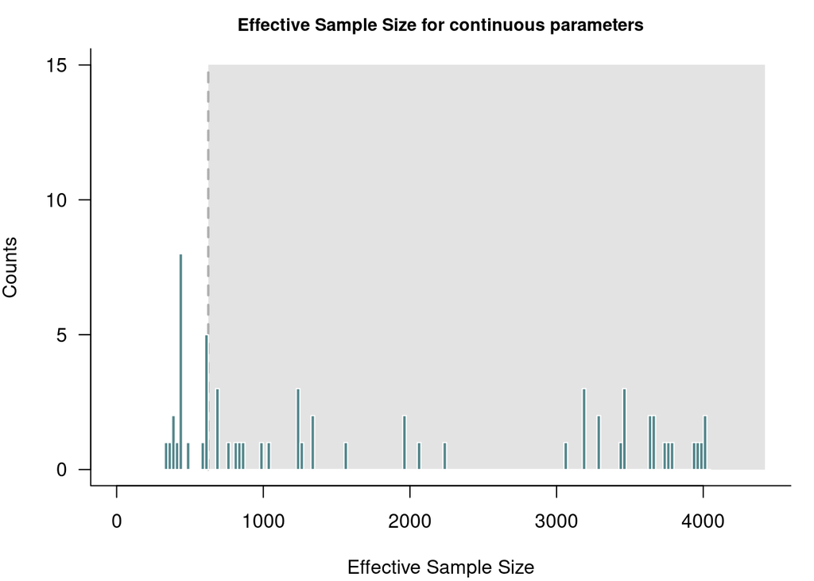

```r
plotEssContinuous(check_HiSSE)
```

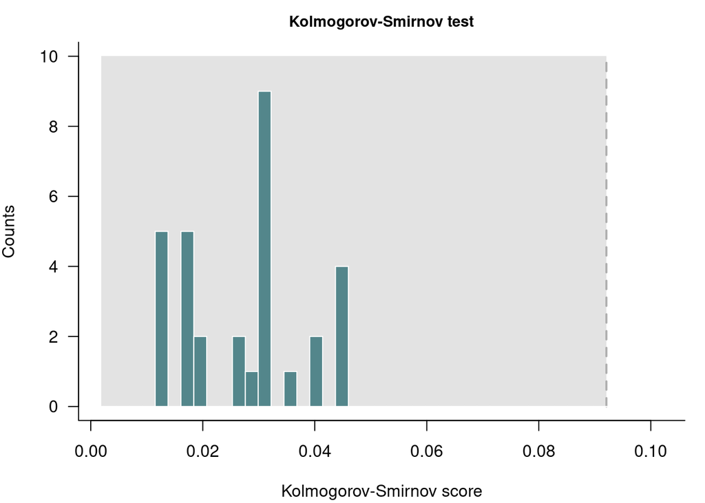

```r
plotKS(check_HiSSE)
```

### Run under prior

I ran the same model without data, i.e. under the prior

```bash
#!bin/bash
#load RevBayes
source ~/Applications/spack/share/setup-env.sh
spack load revbayes /sum2kc5

# run diversification analysis on pruned Coenagrionidae tree
rb_command="source(\"./HiSSE/HiSSE_setup_MAP_prior_pruned.Rev\");"
echo $rb_command | rb
```

And quickly confirm that posterior transition and diversification rates match the priors

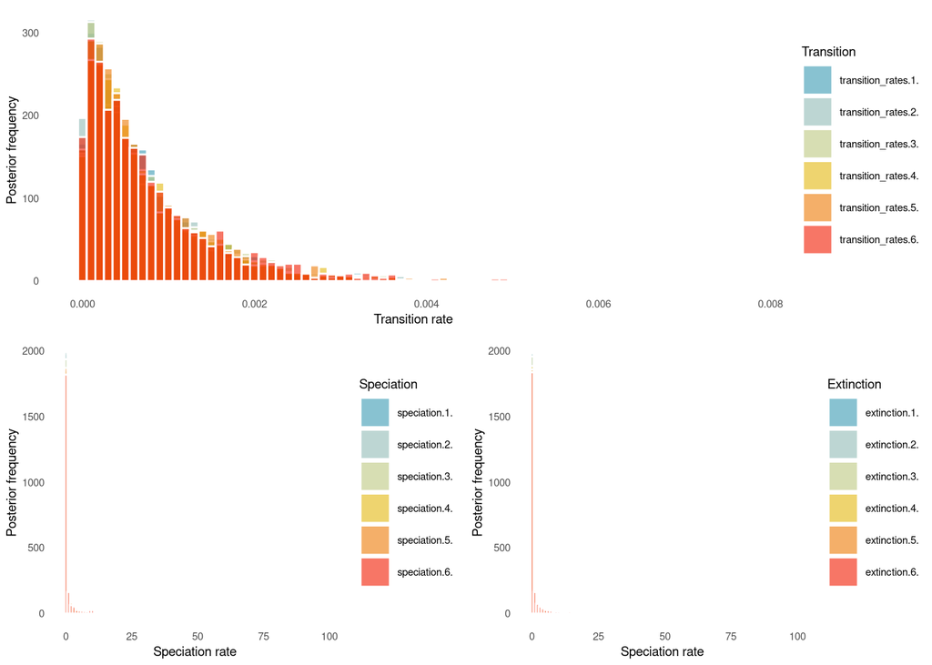

```r
# read posterior of run under prior
pst <- read.table("~/Dropbox/Doctorado/COEN_Comparative/FP_Comparative/output/HiSSE/PolyHiSSE_MAP_coen_prior.model.log", header = T)

# transitions
# reshape to long
prior_t <- pivot_longer(pst, cols = c(42:47), names_to = "Transition", values_to = "Rate")

# get colour palette
pal <- wes_palette("Zissou1", n = 6, type = "continuous")

# plot rates
p_t <- ggplot(prior_t,aes(x = Rate, fill = Transition)) +
   theme_bw(base_size = 8) +
  labs(x = "Transition rate", y = "Posterior frequency") +
  geom_histogram(
    binwidth = 0.0001,
    linewidth = 0.5,
    alpha = 0.6,
    colour = "white",
    position = "identity"
  ) +
  guides(fill = guide_legend(ncol = 1, byrow = TRUE), color = NULL) +
  #xlim(0, 1.0) +
  scale_fill_manual(
    values = pal) +
  theme_minimal(base_size = 7) +
  theme(panel.grid.major = element_blank(),
        panel.grid.minor = element_blank())

# speciation
# reshape to long
prior_s <- pivot_longer(pst, cols = c(28:33), names_to = "Speciation", values_to = "Rate")

# plot rates
p_s <- ggplot(prior_s,aes(x = Rate, fill = Speciation)) +
   theme_bw(base_size = 8) +
  labs(x = "Speciation rate", y = "Posterior frequency") +
  geom_histogram(
    bins=100,
    linewidth = 0.5,
    alpha = 0.6,
    colour = "white",
    position = "identity"
  ) +
  guides(fill = guide_legend(ncol = 1, byrow = TRUE), color = NULL) +
  xlim(-1, 99.0) +
  scale_fill_manual(
    values = pal) +
  theme_minimal(base_size = 7) +
  theme(panel.grid.major = element_blank(),
        panel.grid.minor = element_blank())

# extinction
# reshape to long
prior_e <- pivot_longer(pst, cols = c(5:10), names_to = "Extinction", values_to = "Rate")

# plot rates
p_e <- ggplot(prior_e,aes(x = Rate, fill = Extinction)) +
   theme_bw(base_size = 8) +
  labs(x = "Speciation rate", y = "Posterior frequency") +
  geom_histogram(
    bins=100,
    linewidth = 0.5,
    alpha = 0.6,
    colour = "white",
    position = "identity"
  ) +
  guides(fill = guide_legend(ncol = 1, byrow = TRUE), color = NULL) +
  xlim(-1, 99.0) +
  scale_fill_manual(
    values = pal) +
  theme_minimal(base_size = 7) +
  theme(panel.grid.major = element_blank(),
        panel.grid.minor = element_blank())

lay_matrix <- rbind(c(1,1),
                c(2,3))

grid.arrange(p_t, p_s, p_e, layout_matrix = lay_matrix)
```

### Ancestral states

First, let’s look at the ancestral state estimation. This is to get a sense of the history of sex-related colouration in pond damselflies, but not to address any specific hypothesis.

Run the annotation on RevBayes

```bash
#!bin/bash
#load RevBayes
source ~/Applications/spack/share/setup-env.sh
spack load revbayes /sum2kc5

rb_command="source(\"./HiSSE/Annot_tree.Rev\");"
echo $rb_command | rb
```

```r
# read the annotated tree - it doesn't matter which run we use
stree_fn = "../output/HiSSE/PolyHiSSE_MAP_coen_r1_ase.tre"
stree_fn = "../output/HiSSE/PolyHiSSE_MAP_coen_r2_ase.tre"

# process ancestral states, here we focus on the colour trait only
tre <- processAncStates(stree_fn,
                         state_labels = c("0" = "SM_1",
                                          "1" = "FP_1",
                                          "2" = "SD_1",
                                          "3" = "SM_2",
                                          "4" = "FP_2",
                                          "5" = "SD_2"))
```

```
##   |                                                |                                        |   0%  |                                                |========================================| 100%
```

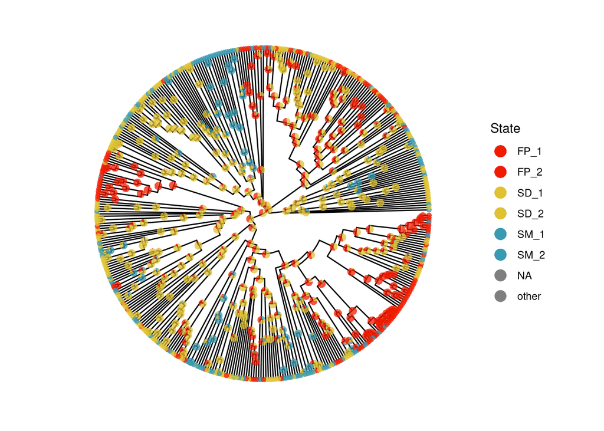

```r
# define colour palette
st_colors = c( wes_palette("Zissou1", n = 12, type = "continuous")[c(12,12,7,7,1,1)], "white" )

# plot tree with ancestral states as pies
zz=plotAncStatesPie(t=tre,
                          pie_colors=st_colors,
                          node_labels_size=0,
                          node_pie_size = 0.75,
                          #node_pie_nudge=0.5,
                          tip_pie_size=0.5,
                          tip_pie_nudge_x = 1,
                          node_pie_nudge_x = 0.5,
                          tip_labels=FALSE,
                          xlim=c(0,106),
                          state_transparency = 0.75,
                          layout="circular"
                          )

zz
```

For completeness, we can plot the ancestral states for the hidden trait that influences diversification dynamics.

```r
# process ancestral states, here we focus on the colour trait only
tre <- processAncStates(stree_fn,
                         state_labels = c("0" = "slow_FP",
                                          "1" = "slow_SM",
                                          "2" = "slow_SD",
                                          "3" = "fast_FP",
                                          "4" = "fast_SM",
                                          "5" = "fast_SD"))
```

```
##   |                                                |                                        |   0%  |                                                |========================================| 100%
```

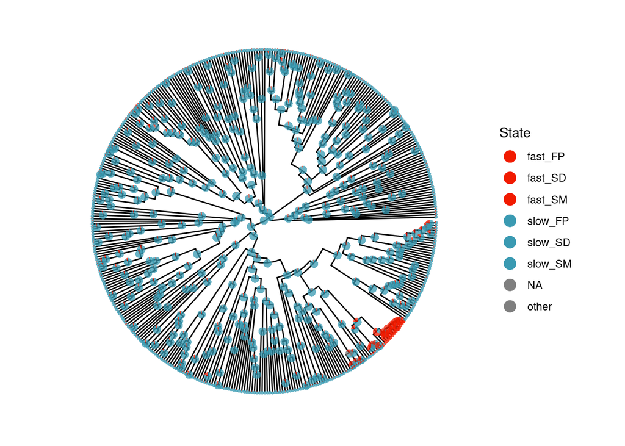

```r
# define colour palette
st_colors = c( wes_palette("Zissou1", n = 12, type = "continuous")[c(12,12,12,1,1,1)], "white" )

# plot tree with ancestral states as pies
zx=plotAncStatesPie(t=tre,
                          pie_colors=st_colors,
                          node_labels_size=0,
                          node_pie_size = 0.75,
                          #node_pie_nudge=0.5,
                          tip_pie_size=0.3,
                          tip_pie_nudge_x = 0.75,
                          node_pie_nudge_x = 0.5,
                          tip_labels=FALSE,
                          xlim=c(0,106),
                          state_transparency = 0.75,
                          layout="circular")
zx
```

```r
#ggsave(plot = zx, filename = "~/Dropbox/Doctorado/COEN_Comparative/Writing/Figures/Hidden_rates.pdf", device = "pdf", width = 160, height = 160, units = "mm", dpi = 600)
```

### Transition rates

Here’s where we test the hypotheses. First, we want to know if FPs are more often descendants from SD lineages than SM lineages.

```r
# read posterior
Hmod1 <- read.table("../output/HiSSE/PolyHiSSE_MAP_coen_r1.model.log", header = T)
Hmod2 <- read.table("../output/HiSSE/PolyHiSSE_MAP_coen_r2.model.log", header = T)

# burn in the first 40,000 iterations and combine
rdat <- rbind(Hmod1[401:4400,c(1,42:47)],Hmod2[401:4400,c(1,42:47)])

# what's the fraction of the posterior in  which SM -> FP > SD -> FP
sum(rdat$transition_rates.1. - rdat$transition_rates.6. > 0) / length(rdat$Iteration)
```

```
## [1] 0.04475
```

```r
# What's the mean and 95% HPD interval of the difference
H1 <- data.frame(mean = mean(rdat$transition_rates.6. - rdat$transition_rates.1.),
                 lwr = HPDinterval(mcmc((rdat$transition_rates.6. - rdat$transition_rates.1.)))[1],
                 upr = HPDinterval(mcmc((rdat$transition_rates.6. - rdat$transition_rates.1.)))[2])

H1 %>%
kbl() %>%
  kable_material(c("striped", "hover"), full_width = F)
```

| mean | lwr | upr |
| --- | --- | --- |
| 0.0043783 | -0.000519 | 0.0098235 |

We’ll plot mean rates for all transitions in Fig 2.

```r
rdat %>% pivot_longer(cols = c(2:7), names_to = "Transition", values_to = "Rate") %>%
  group_by(Transition) %>%
  summarise(mean = mean(Rate))
```

We plot histograms of the transitions rates towards FP for Fig. 2c.

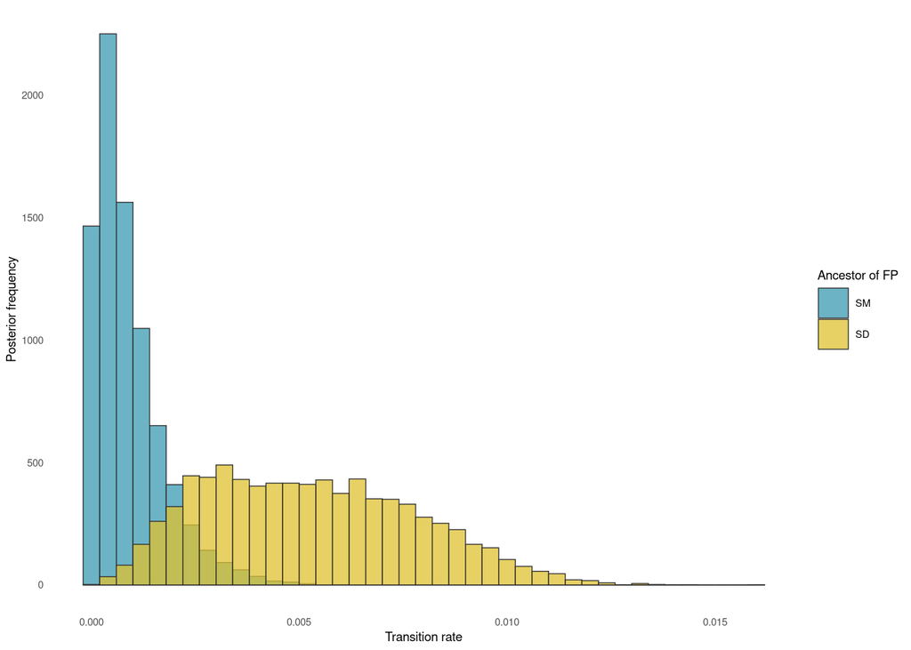

```r
# reshape to long
rdat_long <- pivot_longer(rdat, cols = c(2,7), names_to = "Transition", values_to = "Rate")

# get colour palette
pal <- wes_palette("Zissou1", n = 12, type = "continuous")

# plot rates
p1 <- ggplot(rdat_long,aes(x = Rate, fill = Transition)) +
   theme_bw(base_size = 8) +
  labs(x = "Transition rate", y = "Posterior frequency") +
  geom_histogram(
    binwidth = 0.0004,
    linewidth = 0.25,
    alpha = 0.75,
    colour = "grey20",
    position = "identity"
  ) +
  guides(fill = guide_legend(ncol = 1, byrow = TRUE), color = NULL) +
  #xlim(0, 1.0) +
  scale_fill_manual(
  breaks = c("transition_rates.1.", "transition_rates.6."),
    values = pal[c(1,7)],
    labels = c(
      "SM",
      "SD"
   ),
    name = "Ancestor of FP"
  ) +
  theme_minimal(base_size = 7) +
  theme(panel.grid.major = element_blank(),
        panel.grid.minor = element_blank())
p1
```

Second, we want to know whether SD or SM is the most common descendant of FP.

```r
# read posterior
# what's the fraction of the posterior in  which FP -> SM > FP -> SM
sum(rdat$transition_rates.3. - rdat$transition_rates.4. > 0) / length(rdat$Iteration)
```

```
## [1] 0.473125
```

```r
# What's the mean and 95% HPD interval of the difference
H2 <- data.frame(mean = mean(rdat$transition_rates.4. - rdat$transition_rates.3.),
                 lwr = HPDinterval(mcmc((rdat$transition_rates.4. - rdat$transition_rates.3.)))[1],
                 upr = HPDinterval(mcmc((rdat$transition_rates.4. - rdat$transition_rates.3.)))[2])

H2 %>%
kbl() %>%
  kable_material(c("striped", "hover"), full_width = F)
```

| mean | lwr | upr |
| --- | --- | --- |
| 0.0006824 | -0.0067679 | 0.0088242 |

We plot histograms of the transitions rates away FP for Fig. 2d

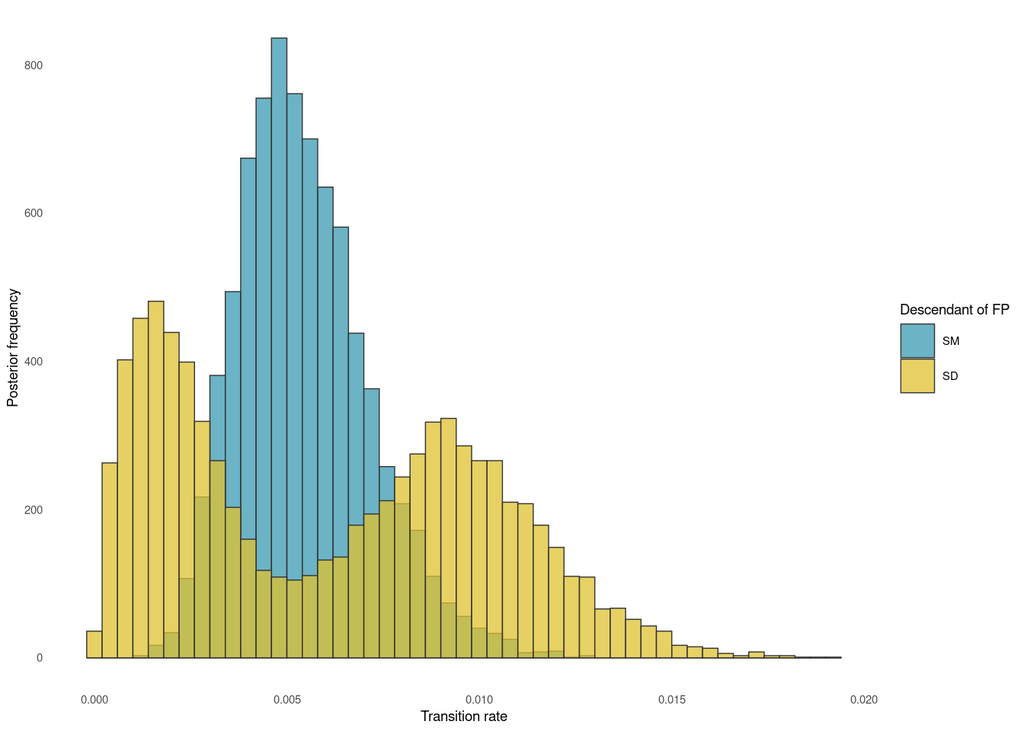

```r
# reshape to long
rdat_long <- pivot_longer(rdat, cols = c(4,5), names_to = "Transition", values_to = "Rate")

# get colour palette
pal <- wes_palette("Zissou1", n = 12, type = "continuous")

# plot rates
p2 <- ggplot(rdat_long, aes(x = Rate, fill = Transition)) +
   theme_bw(base_size = 8) +
  labs(x = "Transition rate", y = "Posterior frequency") +
  geom_histogram(
    binwidth = 0.0004,
    linewidth = 0.25,
    alpha = 0.75,
    colour = "grey20",
    position = "identity"
  ) +
  guides(fill = guide_legend(ncol = 1, byrow = TRUE), color = NULL) +
  #xlim(0, 1.0) +
  scale_fill_manual(
  breaks = c("transition_rates.3.", "transition_rates.4."),
    values = pal[c(1,7)],
    labels = c(
      "SM",
      "SD"
   ),
    name = "Descendant of FP"
  ) +
  theme_minimal(base_size = 7) +
  theme(panel.grid.major = element_blank(),
        panel.grid.minor = element_blank())
p2
```

Create multipanel figure

```r
lay_matrix <- rbind(c(1,1),
                c(1,1),
                c(2,3))

Fig2 <- grid.arrange(zz, p1, p2, layout_matrix = lay_matrix)

#ggsave("../../Writing/Figures/Fig2_V3.pdf", plot = Fig2, device = "pdf", units = "mm", width = 180, height = 160)
```

We plot histograms of the transitions rates between SD and SM for the Supporting Material

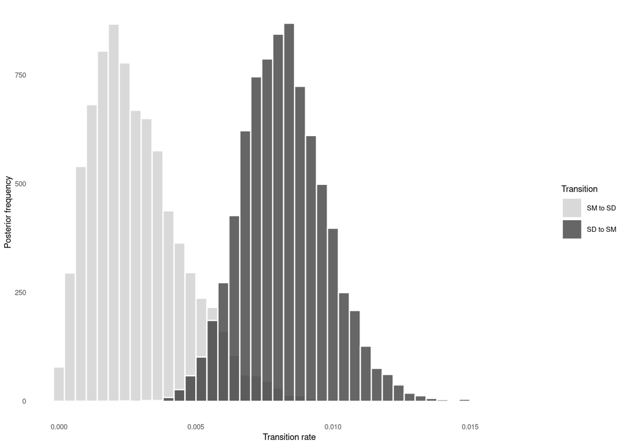

```r
# reshape to long
rdat_long <- pivot_longer(rdat, cols = c(3,6), names_to = "Transition", values_to = "Rate")

# get colour palette
pal <- wes_palette("Zissou1", n = 12, type = "continuous")

# plot rates
p3 <- ggplot(rdat_long,aes(x = Rate, fill = Transition)) +
   theme_bw(base_size = 8) +
  labs(x = "Transition rate", y = "Posterior frequency") +
  geom_histogram(
    binwidth = 0.0004,
    linewidth = 0.5,
    alpha = 0.75,
    colour = "white",
    position = "identity"
  ) +
  guides(fill = guide_legend(ncol = 1, byrow = TRUE), color = NULL) +
  #xlim(0, 1.0) +
  scale_fill_manual(
  breaks = c("transition_rates.2.", "transition_rates.5."),
    values = c("grey80", "grey20"),
    labels = c(
      "SM to SD",
      "SD to SM"
   ),
    name = "Transition"
  ) +
  theme_minimal(base_size = 7) +
  theme(panel.grid.major = element_blank(),
        panel.grid.minor = element_blank())

p3
```

```r
#ggsave("../../Writing/Figures/SM_SD_transitions.pdf", plot = p3, device = "pdf", units = "mm", width = 120, height = 80)
```

### Events

Stochastic character mapping allows us to estimate the number of events for each type of transition.

```r
# it doesn't much matter which run we use
events <- read.table("../output/HiSSE/PolyHiSSE_MAP_coen_r1_events.tsv", header = T)
events <- read.table("../output/HiSSE/PolyHiSSE_MAP_coen_r2_events.tsv", header = T)

SDtoFP <- events %>%
  filter(end_state == 1 | end_state == 4) %>%
  filter(start_state == 2 | start_state == 5) %>%
  group_by(iteration) %>% summarise(n = sum(end_state))

SMtoFP <- events %>%
  filter(end_state == 1 | end_state == 4) %>%
  filter(start_state == 0 | start_state == 3) %>%
  group_by(iteration) %>% summarise(n = sum(end_state))

FPtoSD <- events %>%
  filter(end_state == 2 | end_state == 5) %>%
  filter(start_state == 1 | start_state == 5) %>%
  group_by(iteration) %>% summarise(n = sum(end_state))

FPtoSM <- events %>%
  filter(end_state == 2 | end_state == 5) %>%
  filter(start_state == 1 | start_state == 4) %>%
  group_by(iteration) %>% summarise(n = sum(end_state))

FP_table <- data.frame(FP_transition = rep(c("gain", "loss"), each = 2),
                       from_to = rep(c("SD", "SM"),2),
                       median = c(median(SDtoFP$n),
                                  median(SMtoFP$n),
                                  median(FPtoSD$n),
                                  median(FPtoSM$n)),
                       lwr = c(HPDinterval(mcmc(SDtoFP$n))[1],
                               HPDinterval(mcmc(SMtoFP$n))[1],
                               HPDinterval(mcmc(FPtoSD$n))[1],
                               HPDinterval(mcmc(FPtoSM$n))[1]),
                       upr = c(HPDinterval(mcmc(SDtoFP$n))[2],
                               HPDinterval(mcmc(SMtoFP$n))[2],
                               HPDinterval(mcmc(FPtoSD$n))[2],
                               HPDinterval(mcmc(FPtoSM$n))[2]))

FP_table %>%
  kbl() %>%
  kable_material(c("striped", "hover"), full_width = F)
```

| FP_transition | from_to | median | lwr | upr |
| --- | --- | --- | --- | --- |
| gain | SD | 42 | 4 | 66 |
| gain | SM | 3 | 1 | 12 |
| loss | SD | 89 | 2 | 315 |
| loss | SM | 68 | 2 | 167 |

### Diversification dynamics

We start by plotting diversification rates.

#### Speciation

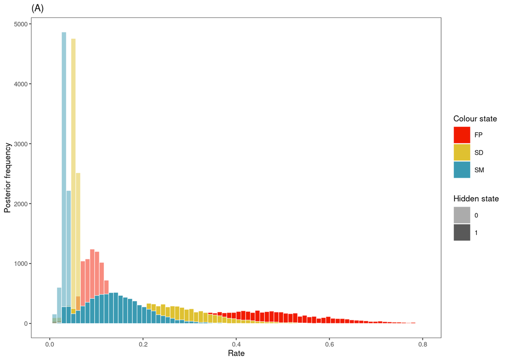

```r
# reshape to long
rdat <- rbind(Hmod1[401:4400,c(1,c(28:33,5:10))],Hmod2[401:4400,c(1,c(28:33,5:10))])

colnames(rdat) <-
  c(
    "Iteration",
    "speciation_SM_0",
    "speciation_FP_0",
    "speciation_SD_0",
    "speciation_SM_1",
    "speciation_FP_1",
    "speciation_SD_1",
    "extinction_SM_0",
    "extinction_FP_0",
    "extinction_SD_0",
    "extinction_SM_1",
    "extinction_FP_1",
    "extinction_SD_1"
  )

rdat_long <- pivot_longer(rdat, cols = c(2:13), names_to = "Event", values_to = "Rate") %>% separate_wider_delim(Event, delim = "_", names=c("Type", "State", "Hidden"))

pal <- wes_palette("Zissou1", 12, type = "continuous")

d1 <- ggplot(data = rdat_long[rdat_long$Type == "speciation",], aes(x = Rate, fill = State, alpha = Hidden)) +
  geom_histogram(bins = 80, colour = "white", position = "identity", size = 0.2) +
  scale_fill_manual(values = pal[c(12,7,1)], name = "Colour state") +
  scale_alpha_manual(values = c(0.5,1), name = "Hidden state") +
  labs(y = "Posterior frequency", title = "(A)") +
  theme_bw(base_size = 8) +
  theme(panel.grid = element_blank()) +
  xlim(0,0.8) #+
  #facet_grid(cols = vars(Hidden), scales = "free")

d1
```

```r
spe_wide <- rdat %>%
  mutate(diff_0vs1_0 = speciation_SM_0 - speciation_FP_0) %>%
  mutate(diff_0vs2_0 = speciation_SM_0 - speciation_SD_0) %>%
  mutate(diff_2vs1_0 = speciation_SD_0 - speciation_FP_0) %>%
  mutate(diff_0vs1_1 = speciation_SM_1 - speciation_FP_1) %>%
  mutate(diff_0vs2_1 = speciation_SM_1 - speciation_SD_1) %>%
  mutate(diff_2vs1_1 = speciation_SD_1 - speciation_FP_1) %>%
  dplyr::select(Iteration, starts_with("diff"))

n <- nrow(spe_wide)

spe_long <- pivot_longer(spe_wide, cols = c(2:7), names_to = "contrast", values_to = "diff") %>%
  separate_wider_delim(cols = contrast, delim = "_", names = c("prefix", "states", "hidden") ) %>%
  dplyr::select(!prefix)

spe_test <- spe_long %>%
  group_by(states, hidden) %>%
  summarise(Mean = mean(diff),
            Lwr = HPDinterval(mcmc(diff))[1],
            Upr = HPDinterval(mcmc(diff))[2],
            PMCMC = sum(diff > 0)/n)

spe_test %>%
  kbl() %>%
  kable_material(c("striped", "hover"), full_width = F)
```

| states | hidden | Mean | Lwr | Upr | PMCMC |
| --- | --- | --- | --- | --- | --- |
| 0vs1 | 0 | -0.0649483 | -0.1156369 | -0.0208205 | 0.000000 |
| 0vs1 | 1 | -0.2669787 | -0.4855430 | -0.0683127 | 0.000000 |
| 0vs2 | 0 | -0.0203889 | -0.0355874 | -0.0043077 | 0.003750 |
| 0vs2 | 1 | -0.0902799 | -0.1909930 | -0.0046078 | 0.003750 |
| 2vs1 | 0 | -0.0445594 | -0.0920571 | -0.0005582 | 0.009375 |
| 2vs1 | 1 | -0.1766988 | -0.3754330 | -0.0081780 | 0.009375 |

#### Extinction

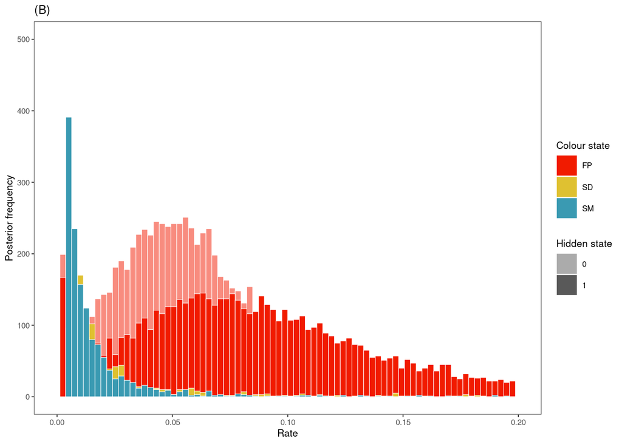

```r
d2 <- ggplot(data = rdat_long[rdat_long$Type == "extinction",], aes(x = Rate, fill = State, alpha = Hidden)) +
  geom_histogram(bins = 80, colour = "white", position = "identity", size = 0.2) +
  scale_fill_manual(values = pal[c(12,7,1)], name = "Colour state") +
  scale_alpha_manual(values = c(0.5,1), name = "Hidden state") +
  labs(y = "Posterior frequency", title = "(B)") +
  theme_bw(base_size = 8) +
  theme(panel.grid = element_blank()) +
  xlim(0,0.2) +
  ylim(0,500)
  #facet_grid(cols = vars(Hidden), scales = "free")

d2
```

```r
ext_wide <- rdat %>%
  mutate(diff_0vs1_0 = extinction_SM_0 - extinction_FP_0) %>%
  mutate(diff_0vs2_0 = extinction_SM_0 - extinction_SD_0) %>%
  mutate(diff_2vs1_0 = extinction_SD_0 - extinction_FP_0) %>%
  mutate(diff_0vs1_1 = extinction_SM_1 - extinction_FP_1) %>%
  mutate(diff_0vs2_1 = extinction_SM_1 - extinction_SD_1) %>%
  mutate(diff_2vs1_1 = extinction_SD_1 - extinction_FP_1) %>%
  dplyr::select(Iteration, starts_with("diff"))

n <- nrow(ext_wide)

ext_long <- pivot_longer(ext_wide, cols = c(2:7), names_to = "contrast", values_to = "diff") %>%
  separate_wider_delim(cols = contrast, delim = "_", names = c("prefix", "states", "hidden") ) %>%
  dplyr::select(!prefix)

ext_test <- ext_long %>%
  group_by(states, hidden) %>%
  summarise(Mean = mean(diff),
            Lwr = HPDinterval(mcmc(diff))[1],
            Upr = HPDinterval(mcmc(diff))[2],
            PMCMC = sum(diff > 0)/n)

ext_test %>%
  kbl() %>%
  kable_material(c("striped", "hover"), full_width = F)
```

| states | hidden | Mean | Lwr | Upr | PMCMC |
| --- | --- | --- | --- | --- | --- |
| 0vs1 | 0 | -0.0454779 | -0.1017026 | 0.0055703 | 0.064500 |
| 0vs1 | 1 | -0.0939605 | -0.2633435 | 0.0246104 | 0.064500 |
| 0vs2 | 0 | -0.0001481 | -0.0126795 | 0.0097767 | 0.482125 |
| 0vs2 | 1 | -0.0036169 | -0.0296310 | 0.0264651 | 0.482125 |
| 2vs1 | 0 | -0.0453298 | -0.1040458 | 0.0070959 | 0.075750 |
| 2vs1 | 1 | -0.0903436 | -0.2912837 | 0.0218272 | 0.075750 |

#### Net diversification

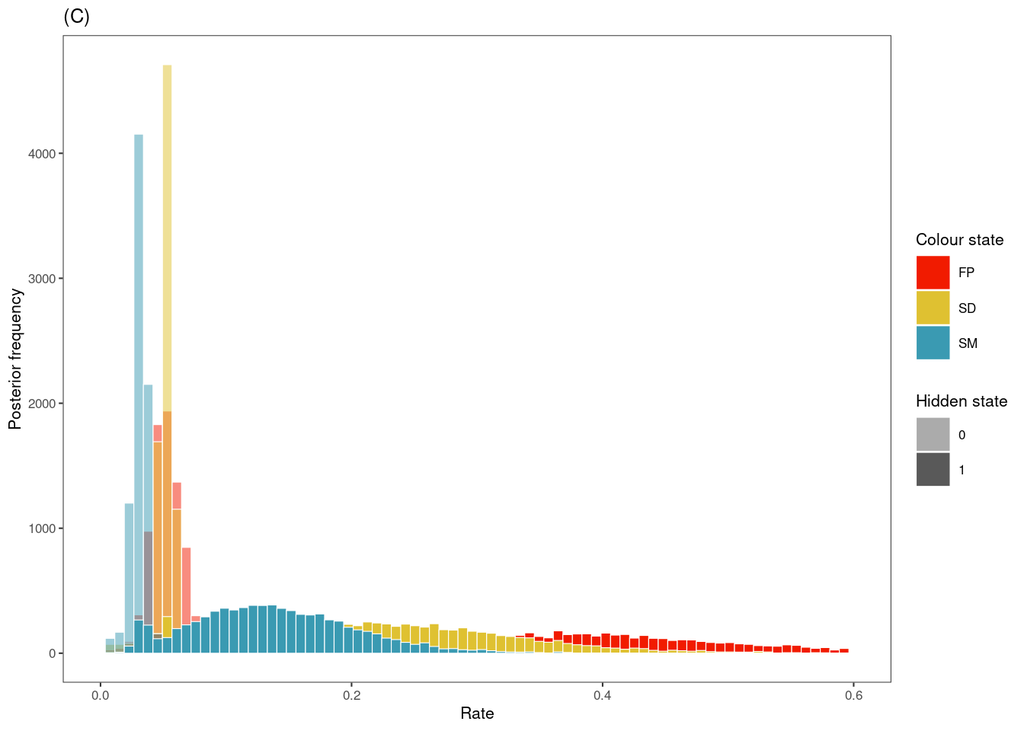

```r
div_dat <- rdat %>%
  mutate(diversification_SM_0 = get("speciation_SM_0") - get("extinction_SM_0")) %>%
  mutate(diversification_FP_0 = get("speciation_FP_0") - get("extinction_FP_0")) %>%
  mutate(diversification_SD_0 = get("speciation_SD_0") - get("extinction_SD_0")) %>%
  mutate(diversification_SM_1 = get("speciation_SM_1") - get("extinction_SM_1")) %>%
  mutate(diversification_FP_1 = get("speciation_FP_1") - get("extinction_FP_1")) %>%
  mutate(diversification_SD_1 = get("speciation_SD_1") - get("extinction_SD_1")) %>%
  dplyr::select(c(1,14:19))

div_dat_long <- pivot_longer(div_dat, cols = c(2:7), names_to = "Event", values_to = "Rate") %>% separate_wider_delim(Event, delim = "_", names=c("Type", "State", "Hidden"))

d3 <- ggplot(data = div_dat_long, aes(x = Rate, fill = State, alpha = Hidden)) +
  geom_histogram(bins = 80, colour = "white", position = "identity", size = 0.2) +
  scale_fill_manual(values = pal[c(12,7,1)], name = "Colour state") +
  scale_alpha_manual(values = c(0.5,1), name = "Hidden state") +
  labs(y = "Posterior frequency", title = "(C)") +
  theme_bw(base_size = 8) +
  theme(panel.grid = element_blank()) +
  xlim(0,0.6) #+
  #facet_grid(cols = vars(Hidden), scales = "free")

d3
```

```r
div_wide <- div_dat %>%
  mutate(diff_0vs1_0 = diversification_SM_0 - diversification_FP_0) %>%
  mutate(diff_0vs2_0 = diversification_SM_0 - diversification_SD_0) %>%
  mutate(diff_2vs1_0 = diversification_SD_0 - diversification_FP_0) %>%
  mutate(diff_0vs1_1 = diversification_SM_1 - diversification_FP_1) %>%
  mutate(diff_0vs2_1 = diversification_SM_1 - diversification_SD_1) %>%
  mutate(diff_2vs1_1 = diversification_SD_1 - diversification_FP_1) %>%
  dplyr::select(Iteration, starts_with("diff"))

n <- nrow(div_wide)

div_long <- pivot_longer(div_wide, cols = c(2:7), names_to = "contrast", values_to = "diff") %>%
  separate_wider_delim(cols = contrast, delim = "_", names = c("prefix", "states", "hidden") ) %>%
  dplyr::select(!prefix)

div_test <- div_long %>%
  group_by(states, hidden) %>%
  summarise(Mean = mean(diff),
            Lwr = HPDinterval(mcmc(diff))[1],
            Upr = HPDinterval(mcmc(diff))[2],
            PMCMC = sum(diff > 0)/n)

div_test %>%
  kbl() %>%
  kable_material(c("striped", "hover"), full_width = F)
```

| states | hidden | Mean | Lwr | Upr | PMCMC |
| --- | --- | --- | --- | --- | --- |
| 0vs1 | 0 | -0.0194704 | -0.0483134 | 0.0067590 | 0.067125 |
| 0vs1 | 1 | -0.1730182 | -0.3988528 | 0.0139063 | 0.040125 |
| 0vs2 | 0 | -0.0202408 | -0.0348651 | -0.0054547 | 0.004250 |
| 0vs2 | 1 | -0.0866630 | -0.1937440 | -0.0057165 | 0.011375 |
| 2vs1 | 0 | 0.0007704 | -0.0271121 | 0.0279462 | 0.511625 |
| 2vs1 | 1 | -0.0863552 | -0.2860556 | 0.0738765 | 0.151000 |

#### Turnover

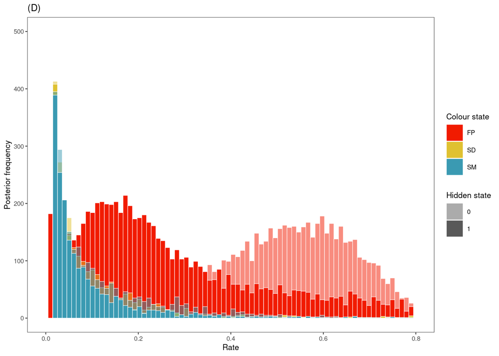

```r
turn_dat <- rdat %>%
  mutate(turnover_SM_0 =  get("extinction_SM_0") / get("speciation_SM_0")) %>%
  mutate(turnover_FP_0 = get("extinction_FP_0") / get("speciation_FP_0")) %>%
  mutate(turnover_SD_0 = get("extinction_SD_0") / get("speciation_SD_0")) %>%
  mutate(turnover_SM_1 = get("extinction_SM_1") / get("speciation_SM_1")) %>%
  mutate(turnover_FP_1 = get("extinction_FP_1") / get("speciation_FP_1")) %>%
  mutate(turnover_SD_1 =  get("extinction_SD_1") / get("speciation_SD_1")) %>%
  dplyr::select(c(1,14:19))

turn_dat_long <- pivot_longer(turn_dat, cols = c(2:7), names_to = "Event", values_to = "Rate") %>% separate_wider_delim(Event, delim = "_", names=c("Type", "State", "Hidden"))

d4 <- ggplot(data = turn_dat_long, aes(x = Rate, fill = State, alpha = Hidden)) +
  geom_histogram(bins = 80, colour = "white", position = "identity", size = 0.2) +
  scale_fill_manual(values = pal[c(12,7,1)], name = "Colour state") +
  scale_alpha_manual(values = c(0.5,1), name = "Hidden state") +
  labs(y = "Posterior frequency", title = "(D)") +
  theme_bw(base_size = 8) +
  theme(panel.grid = element_blank()) +
  xlim(0,0.8) +
  ylim(0,500)
  #facet_grid(cols = vars(Hidden), scales = "free")

d4
```

```r
tur_wide <- turn_dat %>%
  mutate(diff_0vs1_0 = turnover_SM_0 - turnover_FP_0) %>%
  mutate(diff_0vs2_0 = turnover_SM_0 - turnover_SD_0) %>%
  mutate(diff_2vs1_0 = turnover_SD_0 - turnover_FP_0) %>%
  mutate(diff_0vs1_1 = turnover_SM_1 - turnover_FP_1) %>%
  mutate(diff_0vs2_1 = turnover_SM_1 - turnover_SD_1) %>%
  mutate(diff_2vs1_1 = turnover_SD_1 - turnover_FP_1) %>%
  dplyr::select(Iteration, starts_with("diff"))

n <- nrow(tur_wide)

tur_long <- pivot_longer(tur_wide, cols = c(2:7), names_to = "contrast", values_to = "diff") %>%
  separate_wider_delim(cols = contrast, delim = "_", names = c("prefix", "states", "hidden") ) %>%
  dplyr::select(!prefix)

tur_test <- tur_long %>%
  group_by(states, hidden) %>%
  summarise(Mean = mean(diff),
            Lwr = HPDinterval(mcmc(diff))[1],
            Upr = HPDinterval(mcmc(diff))[2],
            PMCMC = sum(diff > 0)/n)
tur_test  %>%
  kbl() %>%
  kable_material(c("striped", "hover"), full_width = F)
```

| states | hidden | Mean | Lwr | Upr | PMCMC |
| --- | --- | --- | --- | --- | --- |
| 0vs1 | 0 | -0.4541238 | -0.7997956 | 0.0800531 | 0.083875 |
| 0vs1 | 1 | -0.2529661 | -0.7511909 | 0.0453717 | 0.083875 |
| 0vs2 | 0 | 0.0116931 | -0.2028536 | 0.3011206 | 0.535500 |
| 0vs2 | 1 | -0.0024753 | -0.1704672 | 0.1793186 | 0.535500 |
| 2vs1 | 0 | -0.4658168 | -0.8111243 | 0.0665318 | 0.080125 |
| 2vs1 | 1 | -0.2504908 | -0.7598707 | 0.0439846 | 0.080125 |

Finally combine results for all diversification rates for a table in the Supporting Material.

```r
rate_type <- rep(c("speciation", "extinction", "net diversification", "turnover"), each = 6)

div_all <- bind_rows(list(spe_test,ext_test,div_test,tur_test)) %>% bind_cols(rate_type) %>%
  rename(Rate_type = ...7) %>% rename(Comparison = states) %>% rename(Hidden = hidden)

div_all  %>%
  kbl() %>%
  kable_material(c("striped", "hover"), full_width = F)

#write.table(div_all, "../output/HiSSE/div_contrasts.tsv", quote = F, row.names = F, sep = "\t")
```

[output not shown]

And combine figures

```r
div_rates <- grid.arrange(d1,d2,d3,d4, nrow=2)

#ggsave(div_rates, filename = "../../Writing/Figures/Div_rates_V2.pdf", device = "pdf", width = 180, height = 120, units = "mm", dpi = 600)
```

# Ecological and demographic predictors of FPs

We used six models to investigate the relationships between ecological factors, demographic factors and the phylogenetic distribution of FP. These analyses can be structured into 4 questions. For each question, we used a multinomial mixed effects model fitted using the package MCMCglmm (Hadfield 2010).

## Are FPs more common in temperate regions and open areas?

See introduction in Willink *et al.* (2024) for the rationale of this hypothesis. *Model 1* uses the literature data to address this question. The model chunk was run on UPPMAX.

### Read and prepare the data

```r
# read in tree
tre <- read.nexus(file = "../data/processed/HiSSE/Willink_MAP_coen.tree")

# read biome data from Willink et al
biodat <- read.csv("../data/processed/glmm/biome_dat.csv", sep = ",", header = T)[,-c(2:5)]

# make latitudinal range variable
biodat$Lat <- factor(paste0(biodat$Biome_1, biodat$Biome_2, biodat$Biome_3))

# revalue levels both warm and cold go to temperate and tropical stays as tropical
biodat$Lat <- dplyr::recode(biodat$Lat, "T" = "Trp", C = "Tmp", "W" = "Tmp", "WC" = "Tmp" )
biodat$Lat[biodat$Lat == "TW" | biodat$Lat == "TWC" | biodat$Lat == ""] <- NA
biodat <- biodat[,c("Taxon", "Lat")]

# number of ambiguous taxa
sum(is.na(biodat$Lat))
```

```
## [1] 83
```

```r
biodat$Lat <- droplevels(biodat$Lat)
#levels(as.factor(biodat$Lat))

# read in opennes data
opendat<-read.csv("../data/processed/glmm/Eco_lit_dat.csv", sep = ",", header = T, na.strings = c("", "NA"), colClasses = rep("factor", 4))[,-c(2,4)]

# number of ambiguous taxa
sum(is.na(opendat$Hab))
```

```
## [1] 106
```

```r
# join data frames
ecodat <- left_join(biodat,opendat) %>%  left_join(femdat)

# filter missing data
ecodat <- ecodat[!is.na(ecodat$State),]

# taxa to row names
rownames(ecodat)<-ecodat$Taxon
```

### General data description

```r
# how many taxa with latitudinal data
nrow(ecodat) - sum(is.na(ecodat$Lat))
```

```
## [1] 356
```

```r
## how many taxa with ambiguous latitudinal distribution
sum(is.na(ecodat$Lat))
```

```
## [1] 62
```

```r
## how many taxa without habitat openness
nrow(ecodat) - sum(is.na(ecodat$Hab))
```

```
## [1] 384
```

```r
## how many taxa with ambiguous habitat openness
length(ecodat$Hab[ecodat$Hab == "C/O"]) - sum(is.na(ecodat$Hab))
```

```
## [1] 50
```

```r
## data prep
# make ambiguous habitats NA
ecodat$Hab[ecodat$Hab == "C/O"] <- NA
ecodat$Hab <- droplevels(ecodat$Hab)

# drop species missing either ecological variable
ecodat <- ecodat[complete.cases(ecodat[,2:3]) == T,]

#write.table(ecodat, "../data/processed/glmm/Eco_lit_dat.tsv", quote = F, row.names = F, sep = "\t")

# number of taxa left
nrow(ecodat)
```

```
## [1] 297
```

```r
# check taxon labels match
matching <- name.check(tre, ecodat, ecodat$Taxon)

# prune tre to match data
ecotre <- drop.tip(tre, matching$tree_not_data, rooted = TRUE)

# fix rounding errors to make ultrametric
ecotre <- nnls.tree(cophenetic(ecotre), ecotre, rooted = TRUE, method = "ultrametric")
```

### Model 1

I ran this model on UPPMAX

```bash
module load R_packages/4.1.1

date

# Run Rscript in a clean R instance, output a logfile
Rscript --vanilla --verbose ./glmm/glmm_mm1.R > slurm-${SLURM_JOBID}.Rout 2>&1

# append logfile to this scripts logfile
cat slurm-${SLURM_JOBID}.Rout >> slurm-${SLURM_JOBID}.out

# remove Rout log
rm slurm-${SLURM_JOBID}.Rout

date
```

#### Run the model

```r
# we need a matrix of phylogenetic distances to account for shared evolutionary history
inv.phylo <- inverseA(ecotre, nodes = "TIPS", scale = TRUE)

# residual covariance matrix 1/J*(I+J), I and J are identity and unit matrices respectively
IJ <- (1/3) * (diag(2) + matrix(1, 2, 2))

# kronecker prior for fixed effect close to being flat for the 2 way:
#(0 vs.1 , 1 vs. 2 and 0 vs. 2) marginal probabilities within each fixed effect
pr1 <- list(
  B = list(mu = rep(0, 8), V = diag(8) * (1.7 + pi ^ 2 / 3)),
  R = list(V = IJ, fix = 1),
  G = list(G1 = list(
    V = IJ,
    nu = 1000,
    alpha.mu = rep(0, 2),
    alpha.V = diag(2)
  ))
)

# run the model without intercept to estimate the probability of each state in each combination of latitude and habitat
mm1 <-
  MCMCglmm(
    State ~ at.level(Hab, 'O'):at.level(Lat, 'Trp'):trait +
      at.level(Hab, 'O'):at.level(Lat, 'Tmp'):trait +
      at.level(Hab, 'C'):at.level(Lat, 'Trp'):trait +
      at.level(Hab, 'C'):at.level(Lat, 'Tmp'):trait - 1,
    random = ~ us(trait):Taxon,
    rcov = ~ us(trait):units,
    ginverse = list(Taxon = inv.phylo$Ainv),
    family = "categorical",
    data = ecodat,
    prior = pr1,
    pl = TRUE,
    slice = TRUE,
    nitt = 330000,
    burnin = 3000,
    thin = 100,
    verbose = f
  )

#write.table(mm1$VCV, file = "../output/glmm/mm1_VCV.tsv", quote = F, row.names = F, sep = "\t")
#write.table(mm1$Sol, file = "../output/glmm/mm1_Sol.tsv", quote = F, row.names = F, sep = "\t")
#write.table(mm1$Liab, file = "../output/glmm/mm1_Liab.tsv", quote = F, row.names = F, sep = "\t")
```

#### Get all intercepts

```r
mm1_Sol <- read.table(file = "../output/glmm/mm1_Sol.tsv", header = T, sep = "\t")

# rescale the intercepts as if the residual covariance matrix was zero
Delta <- cbind(c(-1, 1, 0), c(-1, 0, 1))
c2 <- (16 * sqrt(3)/(15 * pi))^2
D <- ginv(Delta %*% t(Delta)) %*% Delta

# reminder of the residual covariance structure
IJ <- (1/3) * (diag(2) + matrix(1, 2, 2))

# Tropical open habitat
Int1 <- t(apply(mm1_Sol[, 1:2], 1, function(x) {
  D %*% (x/sqrt(1 + c2 * diag(IJ))
  )
}))

Trp_O <- (mcmc(exp(Int1)/rowSums(exp(Int1))))

# Temperate open landscape
Int2 <- t(apply(cbind(mm1_Sol[, 3:4]), 1, function(x) {
  D %*% (x/sqrt(1 + c2 * diag(IJ))
  )
}))

Tmp_O <- (mcmc(exp(Int2)/rowSums(exp(Int2))))

# Tropical closed habitat
Int3 <- t(apply(cbind(mm1_Sol[, 5:6]), 1, function(x) {
  D %*% (x/sqrt(1 + c2 * diag(IJ))
  )
}))

Trp_C <- (mcmc(exp(Int3)/rowSums(exp(Int3))))

# Temperate closed habitat
Int4 <- t(apply(cbind(mm1_Sol[, 7:8]), 1, function(x) {
  D %*% (x/sqrt(1 + c2 * diag(IJ))
  )
}))

Tmp_C <- (mcmc(exp(Int4)/rowSums(exp(Int4))))
```

#### Summary table

Summarise estimates in a table

```r
Eco_FP_lit <- data.frame(Latitude =rep( c("tropical", "temperate"), each = 2),
                         Habitat = rep( c("open", "closed"), 2),
                         SM_mean = c(mean(Trp_O[,1]), mean(Trp_C[,1]), mean(Tmp_O[,1]), mean(Tmp_C[,1])),
                         FP_mean = c(mean(Trp_O[,2]), mean(Trp_C[,2]), mean(Tmp_O[,2]), mean(Tmp_C[,2])),
                         SD_mean = c(mean(Trp_O[,3]), mean(Trp_C[,3]), mean(Tmp_O[,3]), mean(Tmp_C[,3])))


Eco_FP_lit %>% kbl(booktabs =T, align= c(rep('l',2),rep('r', 3))) %>%
kable_styling(latex_options ="striped")
```

| Latitude | Habitat | SM_mean | FP_mean | SD_mean |
| --- | --- | --- | --- | --- |
| tropical | open | 0.3719972 | 0.0955807 | 0.5324222 |
| tropical | closed | 0.5640208 | 0.0391222 | 0.3968570 |
| temperate | open | 0.1136117 | 0.4535288 | 0.4328595 |
| temperate | closed | 0.3012055 | 0.3611345 | 0.3376600 |

```r
#write.table(Eco_FP_lit, file = "../output/glmm/mm1_estimates.tsv", sep = "\t", row.names = F, quote = F)
```

#### Plot

We plot the results separately for each state. First prepare the data for plotting.

```r
pal <- wes_palette("Zissou1", 12, type = "continuous")

n = nrow(mm1_Sol)

# female polymorphism
Plotdat<-data.frame(Lat = rep(c("Tropical", "Temperate", "Tropical", "Temperate"), each = n ),
                   Hab = rep(c("O", "C"), each = 2*n),
                   SM_p = c(Trp_O[,1], Tmp_O[,1], Trp_C[,1], Tmp_C[,1]),
                   FP_p = c(Trp_O[,2], Tmp_O[,2], Trp_C[,2], Tmp_C[,2]),
                   SD_p = c(Trp_O[,3], Tmp_O[,3], Trp_C[,3], Tmp_C[,3]))

Plotdat$Sample<-rownames(Plotdat)
Plotdat$Eco<-paste(Plotdat$Lat, Plotdat$Hab, sep="_")
#head(Plotdat)
```

Ecological effects on the occurrence of sexual monomorphism (SM)

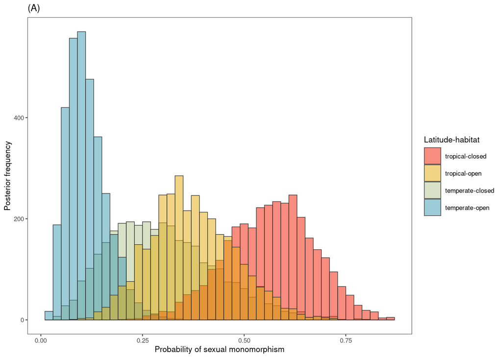

```r
p1.0 <-
   ggplot(Plotdat, aes(x = SM_p, color = Eco, fill = Eco)) + theme_bw(base_size = 8) +
  labs(title = "(A)",
       x = "Probability of sexual monomorphism", y = "Posterior frequency") +
  geom_histogram(
    binwidth = 0.02,
    linewidth = 0.25,
    alpha = 0.5,
    colour = "grey20",
    position = "identity",
    aes(y = after_stat(count))
  ) +
  guides(fill = guide_legend(ncol = 1, byrow = TRUE), color = NULL) +
  #xlim(0, 1.0) +
  scale_fill_manual(
    breaks = c("Tropical_C", "Tropical_O", "Temperate_C", "Temperate_O"),
    values = pal[c(12, 8, 5, 1)],
    labels = c(
      "tropical-closed",
      "tropical-open",
      "temperate-closed",
      "temperate-open"
    ),
    name = "Latitude-habitat"
  ) +
    theme(panel.grid.major = element_blank(),
        panel.grid.minor = element_blank())

p1.0
```

Ecological effects on the occurrence of female polymorphism (FP)

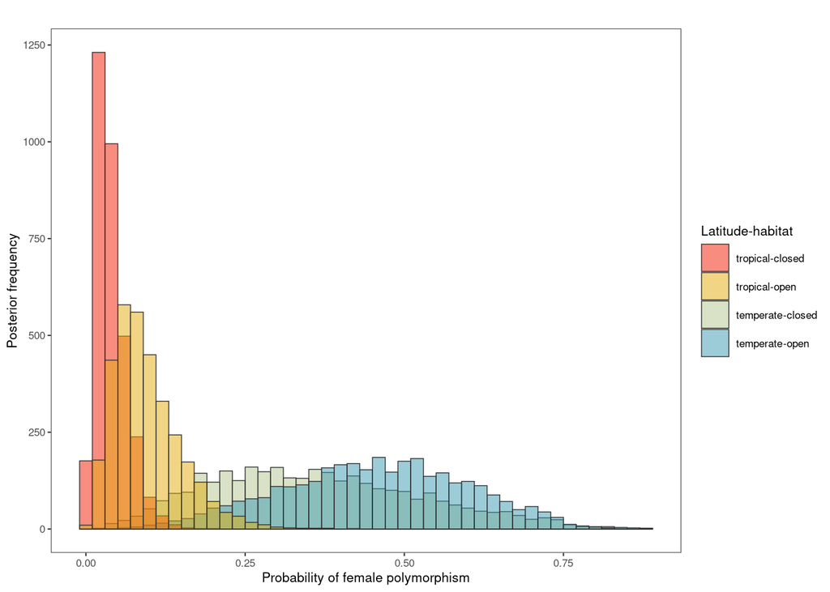

```r
p1.1 <-
  ggplot(Plotdat, aes(x = FP_p, color = Eco, fill = Eco)) + theme_bw(base_size = 8) +
  labs(title = "",
       x = "Probability of female polymorphism", y = "Posterior frequency") +
  geom_histogram(
    binwidth = 0.02,
    linewidth = 0.25,
    alpha = 0.5,
    colour = "grey20",
    position = "identity",
    aes(y = after_stat(count))
  ) +
  guides(fill = guide_legend(ncol = 1, byrow = TRUE), color = NULL) +
  #xlim(0, 1.0) +
  scale_fill_manual(
    breaks = c("Tropical_C", "Tropical_O", "Temperate_C", "Temperate_O"),
    values = pal[c(12, 8, 5, 1)],
    labels = c(
      "tropical-closed",
      "tropical-open",
      "temperate-closed",
      "temperate-open"
    ),
    name = "Latitude-habitat"
  ) +
    theme(panel.grid.major = element_blank(),
        panel.grid.minor = element_blank())

p1.1
```

```r
#ggsave(p1.1,
#       filename = "~/Dropbox/Doctorado/COEN_Comparative/Writing/Figures/Model1_FP.pdf", device = "pdf", units = "mm", width = 80, height = 40)
```

Ecological effects on the occurrence of sexual dimorphism (SD)

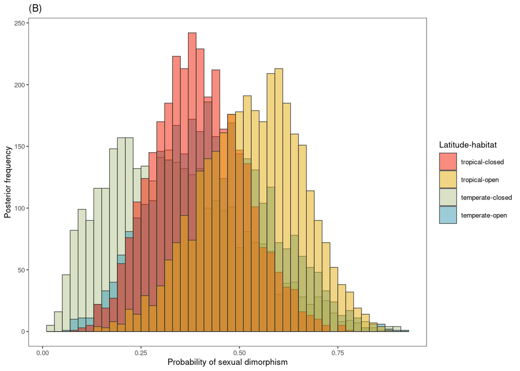

```r
p1.2 <-
  ggplot(Plotdat, aes(x = SD_p, color = Eco, fill = Eco)) + theme_bw(base_size = 8) +
  labs(title = "(B)",
       x = "Probability of sexual dimorphism", y = "Posterior frequency") +
  geom_histogram(
    binwidth = 0.02,
    linewidth = 0.25,
    alpha = 0.5,
    colour = "grey20",
    position = "identity",
    aes(y = after_stat(count))
  ) +
  guides(fill = guide_legend(ncol = 1, byrow = TRUE), color = NULL) +
  #xlim(0, 1.0) +
  scale_fill_manual(
    breaks = c("Tropical_C", "Tropical_O", "Temperate_C", "Temperate_O"),
    values = pal[c(12, 8, 5, 1)],
    labels = c(
      "tropical-closed",
      "tropical-open",
      "temperate-closed",
      "temperate-open"
    ),
    name = "Latitude-habitat"
  ) +
    theme(panel.grid.major = element_blank(),
        panel.grid.minor = element_blank())

p1.2
```

Export SM and SD for Supporting Material

```r
FigS1 <- grid.arrange(p1.0,p1.2, ncol = 2)

ggsave(FigS1,
       filename = "~/Dropbox/Doctorado/COEN_Comparative/Writing/Figures/Model1_SM_SD.pdf", device = "pdf", units = "mm", width = 200, height = 80)
```

#### Hypothesis test

```r
# length of posterior sample
n = length(Tmp_C[,2])

# Temperate vs tropical in open
LatO_m <- mean(Tmp_O[,2] - Trp_O[,2])
LatO_l <- HPDinterval(Tmp_O[,2] - Trp_O[,2])[1]
LatO_u <- HPDinterval(Tmp_O[,2] - Trp_O[,2])[2]
LatO_p <- sum(Trp_O[,2] - Tmp_O[,2] > 0) / n

# Temperate vs tropical in closed
LatC_m <- mean(Tmp_C[,2] - Trp_C[,2])
LatC_l <- HPDinterval(Tmp_C[,2] - Trp_C[,2])[1]
LatC_u <- HPDinterval(Tmp_C[,2] - Trp_C[,2])[2]
LatC_p <- sum(Trp_C[,2] - Tmp_C[,2] > 0) / n

# Open vs closed in tropics
HabTr_m <- mean(Trp_O[,2] - Trp_C[,2])
HabTr_l <- HPDinterval(Trp_O[,2] - Trp_C[,2])[1]
HabTr_u <- HPDinterval(Trp_O[,2] - Trp_C[,2])[2]
HabTr_p <- sum(Trp_C[,2] - Trp_O[,2] > 0) / n

# Open vs closed in tropics
HabTm_m <- mean(Tmp_O[,2] - Tmp_C[,2])
HabTm_l <- HPDinterval(Tmp_O[,2] - Tmp_C[,2])[1]
HabTm_u <- HPDinterval(Tmp_O[,2] - Tmp_C[,2])[2]
HabTm_p <- 1 - (sum(Tmp_O[,2] - Tmp_C[,2] > 0) / n)

# combine in dataframe
FP_tests <- data.frame(Comparsion = c("temperate-open vs tropical-open",
                                      "temperate-closed vs tropical-closed",
                                      "tropical-open vs tropical-closed",
                                      "temperate-open vs temperate-closed"),
                       Mean = c(LatO_m, LatC_m, HabTr_m, HabTm_m),
                       Lower =  c(LatO_l, LatC_l, HabTr_l, HabTm_l),
                       Upper =  c(LatO_u, LatC_u, HabTr_u, HabTm_u),
                       PMCMC =  c(LatO_p, LatC_p, HabTr_p, HabTm_p))

FP_tests  %>%
  kbl(booktabs =T, align= c(rep('l',1),rep('r', 4))) %>%
  kable_styling(latex_options ="striped")
```

| Comparsion | Mean | Lower | Upper | PMCMC |
| --- | --- | --- | --- | --- |
| temperate-open vs tropical-open | 0.3579481 | 0.1151845 | 0.5922740 | 0.0003058 |
| temperate-closed vs tropical-closed | 0.3220123 | 0.0601452 | 0.6529775 | 0.0009174 |
| tropical-open vs tropical-closed | 0.0564585 | -0.0249451 | 0.1656533 | 0.0773700 |
| temperate-open vs temperate-closed | 0.0923943 | -0.2099826 | 0.4155171 | 0.2749235 |

```r
# length of posterior sample
n = length(Tmp_C[,1])

# Temperate vs tropical in open
LatO_m <- mean(Tmp_O[,1] - Trp_O[,1])
LatO_l <- HPDinterval(Tmp_O[,1] - Trp_O[,1])[1]
LatO_u <- HPDinterval(Tmp_O[,1] - Trp_O[,1])[2]
LatO_p <- 1 - (sum(Trp_O[,1] - Tmp_O[,1] > 0) / n)

# Temperate vs tropical in closed
LatC_m <- mean(Tmp_C[,1] - Trp_C[,1])
LatC_l <- HPDinterval(Tmp_C[,1] - Trp_C[,1])[1]
LatC_u <- HPDinterval(Tmp_C[,1] - Trp_C[,1])[2]
LatC_p <- 1 - (sum(Trp_C[,1] - Tmp_C[,1] > 0) / n)

# Open vs closed in tropics
HabTr_m <- mean(Trp_O[,1] - Trp_C[,1])
HabTr_l <- HPDinterval(Trp_O[,1] - Trp_C[,1])[1]
HabTr_u <- HPDinterval(Trp_O[,1] - Trp_C[,1])[2]
HabTr_p <- 1 - (sum(Trp_C[,1] - Trp_O[,1] > 0) / n)

# Open vs closed in tropics
HabTm_m <- mean(Tmp_O[,1] - Tmp_C[,1])
HabTm_l <- HPDinterval(Tmp_O[,1] - Tmp_C[,1])[1]
HabTm_u <- HPDinterval(Tmp_O[,1] - Tmp_C[,1])[2]
HabTm_p <- sum(Tmp_O[,1] - Tmp_C[,1] > 0) / n

# combine in dataframe
SM_tests <- data.frame(Comparsion = c("temperate-open vs tropical-open",
                                      "temperate-closed vs tropical-closed",
                                      "tropical-open vs tropical-closed",
                                      "temperate-open vs temperate-closed"),
                       Mean = c(LatO_m, LatC_m, HabTr_m, HabTm_m),
                       Lower =  c(LatO_l, LatC_l, HabTr_l, HabTm_l),
                       Upper =  c(LatO_u, LatC_u, HabTr_u, HabTm_u),
                       PMCMC =  c(LatO_p, LatC_p, HabTr_p, HabTm_p))

SM_tests  %>%
  kbl(booktabs =T, align= c(rep('l',1),rep('r', 4))) %>%
  kable_styling(latex_options ="striped")
```

| Comparsion | Mean | Lower | Upper | PMCMC |
| --- | --- | --- | --- | --- |
| temperate-open vs tropical-open | -0.2583855 | -0.4700423 | -0.0763370 | 0.0039755 |
| temperate-closed vs tropical-closed | -0.2628154 | -0.5421785 | 0.0462706 | 0.0489297 |
| tropical-open vs tropical-closed | -0.1920237 | -0.4099427 | -0.0076624 | 0.0327217 |
| temperate-open vs temperate-closed | -0.1875938 | -0.4551042 | 0.0344990 | 0.0529052 |

```r
# length of posterior sample
n = length(Tmp_C[,3])

# Temperate vs tropical in open
LatO_m <- mean(Tmp_O[,3] - Trp_O[,3])
LatO_l <- HPDinterval(Tmp_O[,3] - Trp_O[,3])[1]
LatO_u <- HPDinterval(Tmp_O[,3] - Trp_O[,3])[2]
LatO_p <- 1 - (sum(Trp_O[,3] - Tmp_O[,3] > 0) / n)

# Temperate vs tropical in closed
LatC_m <- mean(Tmp_C[,3] - Trp_C[,3])
LatC_l <- HPDinterval(Tmp_C[,3] - Trp_C[,3])[1]
LatC_u <- HPDinterval(Tmp_C[,3] - Trp_C[,3])[2]
LatC_p <- 1 - (sum(Trp_C[,3] - Tmp_C[,3] > 0) / n)

# Open vs closed in tropics
HabTr_m <- mean(Trp_O[,3] - Trp_C[,3])
HabTr_l <- HPDinterval(Trp_O[,3] - Trp_C[,3])[1]
HabTr_u <- HPDinterval(Trp_O[,3] - Trp_C[,3])[2]
HabTr_p <- sum(Trp_C[,3] - Trp_O[,3] > 0) / n

# Open vs closed in tropics
HabTm_m <- mean(Tmp_O[,3] - Tmp_C[,3])
HabTm_l <- HPDinterval(Tmp_O[,3] - Tmp_C[,3])[1]
HabTm_u <- HPDinterval(Tmp_O[,3] - Tmp_C[,3])[2]
HabTm_p <- 1 - (sum(Tmp_O[,3] - Tmp_C[,3] > 0) / n)

# combine in dataframe
SD_tests <- data.frame(Comparsion = c("temperate-open vs tropical-open",
                                      "temperate-closed vs tropical-closed",
                                      "tropical-open vs tropical-closed",
                                      "temperate-open vs temperate-closed"),
                       Mean = c(LatO_m, LatC_m, HabTr_m, HabTm_m),
                       Lower =  c(LatO_l, LatC_l, HabTr_l, HabTm_l),
                       Upper =  c(LatO_u, LatC_u, HabTr_u, HabTm_u),
                       PMCMC =  c(LatO_p, LatC_p, HabTr_p, HabTm_p))

SD_tests  %>%
  kbl(booktabs =T, align= c(rep('l',1),rep('r', 4))) %>%
  kable_styling(latex_options ="striped")
```

| Comparsion | Mean | Lower | Upper | PMCMC |
| --- | --- | --- | --- | --- |
| temperate-open vs tropical-open | -0.0995627 | -0.3614189 | 0.1427201 | 0.2293578 |
| temperate-closed vs tropical-closed | -0.0591969 | -0.3809587 | 0.2892279 | 0.3422018 |
| tropical-open vs tropical-closed | 0.1355652 | -0.0870159 | 0.3455783 | 0.1091743 |
| temperate-open vs temperate-closed | 0.0951994 | -0.2365086 | 0.4180145 | 0.2773700 |

Combine tables for Supporting Material

```r
Htests <- bind_rows(list(SM_tests,FP_tests, SD_tests), .id = "State") %>%
  mutate(State=factor(State, labels=c('SM', "FP", 'SD')))

write.table(Htests, file = "../output/glmm/mm1_Htests.tsv", sep = "\t", row.names = F, quote = F)
```

### Repeat with field data only (Model 2)

In *Model 2*, we make sure this general pattern holds for the subset of data collected in the field.

#### Read and prepare the data

```r
# Read in lit data
dat<-read.csv("../data/processed/glmm/Field_comp_dat.csv", sep = ",", header = T, na.strings = c("", "NA"), colClasses = c(rep("factor", 8), rep("numeric",3)))

# drop species missing either ecological variable
dat <- dat[complete.cases(dat[,6:8]) == T,]

# number of taxa left
nrow(dat)
```

```
## [1] 244
```

```r
# prune data not in tree (featherlegs)
matching <- name.check(tre, dat, dat$Taxon)

ecodat2 <- dat[!(dat$Taxon %in% matching$data_not_tree),]

# prune trees to match data
ecotre2<-drop.tip(tre, matching$tree_not_data, rooted = TRUE)

# fix rounding errors to make ultrametric
ecotre2 <- nnls.tree(cophenetic(ecotre2), ecotre2, rooted = TRUE, method = "ultrametric")
```

#### Run the model

```r
# we need a matrix of phylogenetic distances to account for shared evolutionary history
inv.phylo <- inverseA(ecotre2, nodes = "TIPS", scale = TRUE)

# residual covariance matrix 1/J*(I+J), I and J are identity and unit matrices respectively
IJ <- (1/3) * (diag(2) + matrix(1, 2, 2))

# kronecker prior for fixed effect close to being flat for the 2 way:
#(0 vs.1 , 1 vs. 2 and 0 vs. 2) marginal probabilities within each fixed effect
pr1 <- list(
  B = list(mu = rep(0, 8), V = diag(8) * (1.7 + pi ^ 2 / 3)),
  R = list(V = IJ, fix = 1),
  G = list(
    G1 = list(
      V = IJ,
      nu = 1000,
      alpha.mu = rep(0, 2),
      alpha.V = diag(2)
    ),
    G2 = list(
      V = 1,
      nu = 1000,
      alpha.mu = rep(0, 1),
      alpha.V = diag(1)
    )
  )
)

# run the model without intercept to estimate the probability of each state in each combination of latitude and habitat
# with SM as baseline for log-odds
mm2.1 <-
  MCMCglmm(
    relevel(FemState, ref="0") ~ at.level(Hab, 'O'):at.level(Lat, 'Trp'):trait +
      at.level(Hab, 'O'):at.level(Lat, 'Tmp'):trait +
      at.level(Hab, 'C'):at.level(Lat, 'Trp'):trait +
      at.level(Hab, 'C'):at.level(Lat, 'Tmp'):trait - 1,
    random = ~ us(trait):Taxon + Site,
    rcov = ~ us(trait):units,
    ginverse = list(Taxon = inv.phylo$Ainv),
    family = "categorical",
    data = ecodat2,
    prior = pr1,
    pl = TRUE,
    slice = TRUE,
    nitt = 330000,
    burnin = 30000,
    thin = 100,
    verbose = F
  )

# with SD as baseline for log-odds
mm2.2 <-
  MCMCglmm(
    relevel(FemState, ref="2") ~ at.level(Hab, 'O'):at.level(Lat, 'Trp'):trait +
      at.level(Hab, 'O'):at.level(Lat, 'Tmp'):trait +
      at.level(Hab, 'C'):at.level(Lat, 'Trp'):trait +
      at.level(Hab, 'C'):at.level(Lat, 'Tmp'):trait - 1,
    random = ~ us(trait):Taxon + Site,
    rcov = ~ us(trait):units,
    ginverse = list(Taxon = inv.phylo$Ainv),
    family = "categorical",
    data = ecodat2,
    prior = pr1,
    pl = TRUE,
    slice = TRUE,
    nitt = 330000,
    burnin = 30000,
    thin = 100,
    verbose = F
  )
```

#### Get all intercepts

```r
# rescale the intercepts as if the residual covariance matrix was zero
Delta <- cbind(c(-1, 1, 0), c(-1, 0, 1))
c2 <- (16 * sqrt(3)/(15 * pi))^2
D <- ginv(Delta %*% t(Delta)) %*% Delta

# Tropical open habitat
Int1 <- t(apply(mm2.1$Sol[, 1:2], 1, function(x) {
  D %*% (x/sqrt(1 + c2 * diag(IJ))
  )
}))

Trp_O<- (mcmc(exp(Int1)/rowSums(exp(Int1))))

# Temperate open landscape
Int2 <- t(apply(cbind(mm2.1$Sol[, 3:4]), 1, function(x) {
  D %*% (x/sqrt(1 + c2 * diag(IJ))
  )
}))

Tmp_O<-(mcmc(exp(Int2)/rowSums(exp(Int2)))) #

# Tropical closed habitat
Int3 <- t(apply(cbind(mm2.1$Sol[, 5:6]), 1, function(x) {
  D %*% (x/sqrt(1 + c2 * diag(IJ))
  )
}))

Trp_C<-(mcmc(exp(Int3)/rowSums(exp(Int3))))

# Temperate closed habitat
Int4 <- t(apply(cbind(mm2.1$Sol[, 7:8]), 1, function(x) {
  D %*% (x/sqrt(1 + c2 * diag(IJ))
  )
}))

Tmp_C<-(mcmc(exp(Int4)/rowSums(exp(Int4))))
```

#### Summary table

```r
Eco_FP_field <- data.frame(Latitude =rep( c("Tropical", "Temperate"), each = 2),
                         Habitat = rep( c("open", "closed"), 2),
                         SM_mean = c(mean(Trp_O[,1]), mean(Trp_C[,1]), mean(Tmp_O[,1]), mean(Tmp_C[,1])),
                         SD_mean = c(mean(Trp_O[,3]), mean(Trp_C[,3]), mean(Tmp_O[,3]), mean(Tmp_C[,3])),
                         FP_mean = c(mean(Trp_O[,2]), mean(Trp_C[,2]), mean(Tmp_O[,2]), mean(Tmp_C[,2])))

Eco_FP_field %>% kbl(booktabs =T, align= c(rep('l',2),rep('r', 3))) %>%
kable_styling(latex_options ="striped")
```

| Latitude | Habitat | SM_mean | SD_mean | FP_mean |
| --- | --- | --- | --- | --- |
| Tropical | open | 0.1111269 | 0.7205349 | 0.1683382 |
| Tropical | closed | 0.5828908 | 0.3139049 | 0.1032042 |
| Temperate | open | 0.0401455 | 0.1227519 | 0.8371026 |
| Temperate | closed | 0.4984352 | 0.3991868 | 0.1023780 |

```r
Eco_FP <- rbind(Eco_FP_lit, Eco_FP_field)
Eco_FP$Source <- rep (c("literature", "field"), each = 4)

Eco_FP <- Eco_FP[,c(6,1:5)]

Eco_FP %>% kbl(booktabs =T, align= c(rep('l',3),rep('r', 3))) %>%
kable_styling(latex_options ="striped")
```

| Source | Latitude | Habitat | SM_mean | FP_mean | SD_mean |
| --- | --- | --- | --- | --- | --- |
| literature | tropical | open | 0.3719972 | 0.0955807 | 0.5324222 |
| literature | tropical | closed | 0.5640208 | 0.0391222 | 0.3968570 |
| literature | temperate | open | 0.1136117 | 0.4535288 | 0.4328595 |
| literature | temperate | closed | 0.3012055 | 0.3611345 | 0.3376600 |
| field | Tropical | open | 0.1111269 | 0.1683382 | 0.7205349 |
| field | Tropical | closed | 0.5828908 | 0.1032042 | 0.3139049 |
| field | Temperate | open | 0.0401455 | 0.8371026 | 0.1227519 |
| field | Temperate | closed | 0.4984352 | 0.1023780 | 0.3991868 |

#### Plot

We plot the results separately for each state. First prepare the data for plotting.

```r
pal <- wes_palette("Zissou1", 12, type = "continuous")

n = nrow(mm2.1$Sol)

#Female polymorphism
Plotdat<-data.frame(Lat = rep(c("Tropical", "Temperate", "Tropical", "Temperate"), each = n ),
                   Hab = rep(c("O", "C"), each = 2*n),
                   SM_p = c(Trp_O[,1], Tmp_O[,1], Trp_C[,1], Tmp_C[,1]),
                   FP_p = c(Trp_O[,2], Tmp_O[,2], Trp_C[,2], Tmp_C[,2]),
                   SD_p = c(Trp_O[,3], Tmp_O[,3], Trp_C[,3], Tmp_C[,3]))

Plotdat$Sample<-rownames(Plotdat)
Plotdat$Eco<-paste(Plotdat$Lat, Plotdat$Hab, sep="_")
```

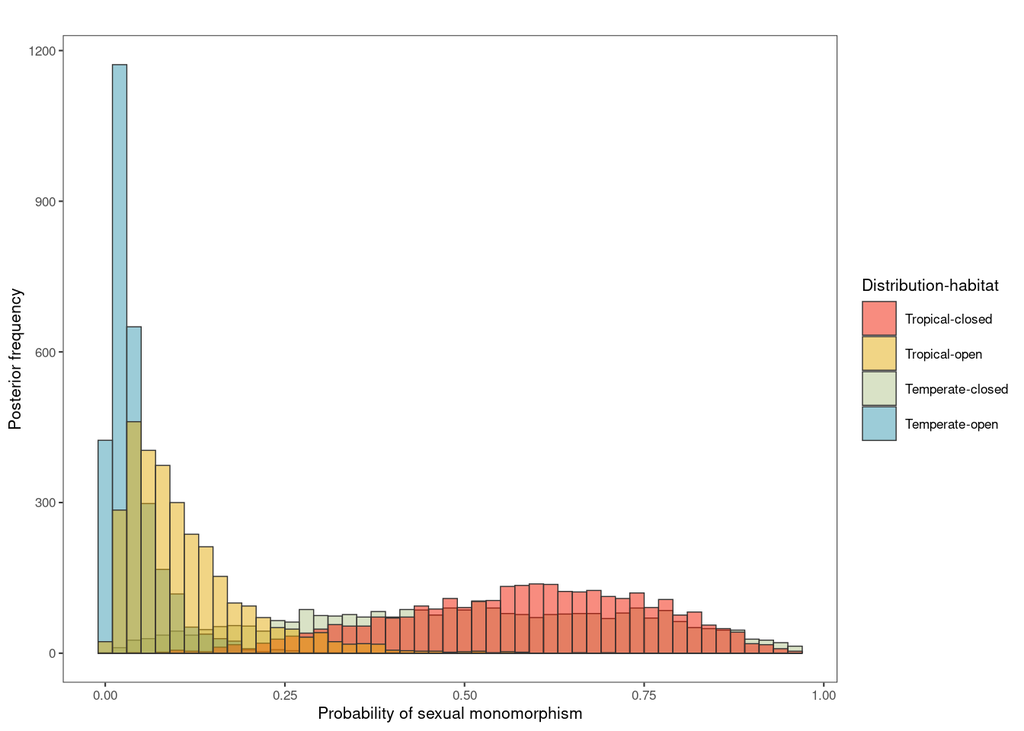

```r
p2.0 <-
   ggplot(Plotdat, aes(x = SM_p, color = Eco, fill = Eco)) + theme_bw(base_size = 8) +
  labs(title = "",
       x = "Probability of sexual monomorphism", y = "Posterior frequency") +
  geom_histogram(
    binwidth = 0.02,
    linewidth = 0.25,
    alpha = 0.5,
    colour = "grey20",
    position = "identity",
    aes(y = after_stat(count))
  ) +
  guides(fill = guide_legend(ncol = 1, byrow = TRUE), color = NULL) +
  #xlim(0, 1.0) +
  scale_fill_manual(
    breaks = c("Tropical_C", "Tropical_O", "Temperate_C", "Temperate_O"),
    values = pal[c(12, 8, 5, 1)],
    labels = c(
      "Tropical-closed",
      "Tropical-open",
      "Temperate-closed",
      "Temperate-open"
    ),
    name = "Distribution-habitat"
  ) +
    theme(panel.grid.major = element_blank(),
        panel.grid.minor = element_blank())

p2.0
```

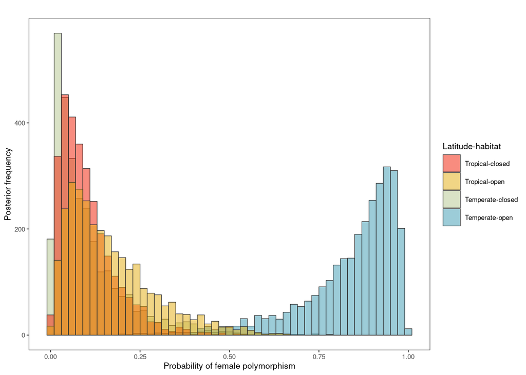

```r
p2.1 <-
  ggplot(Plotdat, aes(x = FP_p, color = Eco, fill = Eco)) + theme_bw(base_size = 8) +
  labs(title = "",
       x = "Probability of female polymorphism", y = "Posterior frequency") +
  geom_histogram(
    binwidth = 0.02,
    linewidth = 0.25,
    alpha = 0.5,
    colour = "grey20",
    position = "identity",
    aes(y = after_stat(count))
  ) +
  guides(fill = guide_legend(ncol = 1, byrow = TRUE), color = NULL) +
  #xlim(0, 1.0) +
  scale_fill_manual(
    breaks = c("Tropical_C", "Tropical_O", "Temperate_C", "Temperate_O"),
    values = pal[c(12, 8, 5, 1)],
    labels = c(
      "Tropical-closed",
      "Tropical-open",
      "Temperate-closed",
      "Temperate-open"
    ),
    name = "Latitude-habitat"
  ) +
    theme(panel.grid.major = element_blank(),
        panel.grid.minor = element_blank())

p2.1
```

```r
#ggsave(p2.1,
#       filename = "~/Dropbox/Doctorado/COEN_Comparative/Writing/Figures/Model2_FP.pdf", device = "pdf", units = "mm", width = 80, height = 40)
```

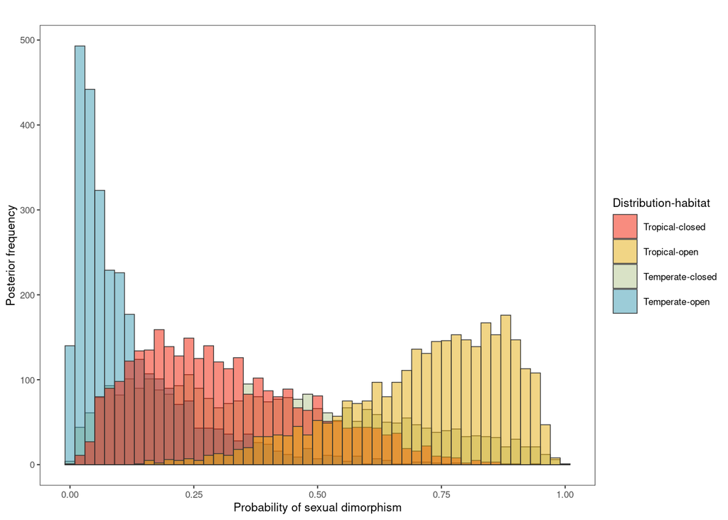

```r
p2.2 <-
  ggplot(Plotdat, aes(x = SD_p, color = Eco, fill = Eco)) + theme_bw(base_size = 8) +
  labs(title = "",
       x = "Probability of sexual dimorphism", y = "Posterior frequency") +
  geom_histogram(
    binwidth = 0.02,
    linewidth = 0.25,
    alpha = 0.5,
    colour = "grey20",
    position = "identity",
    aes(y = after_stat(count))
  ) +
  guides(fill = guide_legend(ncol = 1, byrow = TRUE), color = NULL) +
  #xlim(0, 1.0) +
  scale_fill_manual(
    breaks = c("Tropical_C", "Tropical_O", "Temperate_C", "Temperate_O"),
    values = pal[c(12, 8, 5, 1)],
    labels = c(
      "Tropical-closed",
      "Tropical-open",
      "Temperate-closed",
      "Temperate-open"
    ),
    name = "Distribution-habitat"
  ) +
    theme(panel.grid.major = element_blank(),
        panel.grid.minor = element_blank())

p2.2
```

#### Hypothesis test

```r
# length of posterior sample
n = length(Tmp_C[,2])

# Temperate vs tropical in open
LatO_m <- mean(Tmp_O[,2] - Trp_O[,2])
LatO_l <- HPDinterval(Tmp_O[,2] - Trp_O[,2])[1]
LatO_u <- HPDinterval(Tmp_O[,2] - Trp_O[,2])[2]
LatO_p <- sum(Trp_O[,2] - Tmp_O[,2] > 0) / n

# Temperate vs tropical in closed
LatC_m <- mean(Tmp_C[,2] - Trp_C[,2])
LatC_l <- HPDinterval(Tmp_C[,2] - Trp_C[,2])[1]
LatC_u <- HPDinterval(Tmp_C[,2] - Trp_C[,2])[2]
LatC_p <- sum(Trp_C[,2] - Tmp_C[,2] > 0) / n

# Open vs closed in tropics
HabTr_m <- mean(Trp_O[,2] - Trp_C[,2])
HabTr_l <- HPDinterval(Trp_O[,2] - Trp_C[,2])[1]
HabTr_u <- HPDinterval(Trp_O[,2] - Trp_C[,2])[2]
HabTr_p <- sum(Trp_C[,2] - Trp_O[,2] > 0) / n

# Open vs closed in tropics
HabTm_m <- mean(Tmp_C[,1] - Tmp_O[,1])
HabTm_l <- HPDinterval(Tmp_C[,1] - Tmp_O[,1])[1]
HabTm_u <- HPDinterval(Tmp_C[,1] - Tmp_O[,1])[2]
HabTm_p <- sum(Tmp_O[,1] - Tmp_C[,1] > 0) / n

# combine in dataframe
FP_tests <- data.frame(comparsion = c("Temperate-open vs Tropical-open",
                                      "Temperate-closed vs Tropical-closed",
                                      "Tropical-open vs Tropical-closed",
                                      "Temperate-open vs Temperate-closed"),
                       mean = c(LatO_m, LatC_m, HabTr_m, HabTm_m),
                       lower =  c(LatO_l, LatC_l, HabTr_l, HabTm_l),
                       upper =  c(LatO_u, LatC_u, HabTr_u, HabTm_u),
                       pMCMC =  c(LatO_p, LatC_p, HabTr_p, HabTm_p))

FP_tests  %>%
  kbl(booktabs =T, align= c(rep('l',1),rep('r', 4))) %>%
  kable_styling(latex_options ="striped")
```

[output not shown]

## Are FLCPs more common in in species with high breeding density and male-biased OSR?

See introduction in Willink *et al.* (2024) for the rationale of this hypothesis.

### Summary of field sampling

```r
# How many breeding sites per country?
site_count <- aggregate(ecodat2$Site, by = list(ecodat2$Country), FUN = length)
site_count  %>%
  kbl() %>%
  kable_material(c("striped", "hover"), full_width = F)
```

| Group.1 | x |
| --- | --- |
| Argentina | 19 |
| Cameroon | 41 |
| Costa Rica | 48 |
| Cyprus | 17 |
| Guyana | 20 |
| NewZealand | 1 |
| Sweden | 37 |
| USA | 25 |

```r
# Effort per site
site_time <- aggregate(ecodat2$Time, by = list(ecodat2$Site), FUN = sum)

effort <- data.frame(stat = c("min", "max", "mean", "sd"),
                     value = c(min(site_time$x/60),
                               max(site_time$x/60),
                               mean(site_time$x/60),
                               sd(site_time$x/60)))
effort %>%
kbl(booktabs =T, align= c('l','r')) %>%
kable_styling(latex_options ="striped")
```

| stat | value |
| --- | --- |
| min | 0.200000 |
| max | 16.333333 |
| mean | 2.572917 |
| sd | 3.180338 |

### Prepare the density data

```r
# total number or individuals
ecodat2$Total <- ecodat2$Female + ecodat2$Male

# zero - centered time so we can compare intercepts later on
ecodat2$TimeC <- scale(log(ecodat2$Time), center = TRUE, scale = FALSE)

# density
ecodat2$dens <- ecodat2$Total / ecodat2$Time * 60
```

### Prepare the OSR data

```r
# males per female
ecodat2$OSR <- (ecodat2$Male+1) / (ecodat2$Female+1)
```

### How are the raw density and OSR data distributed

For Fig. 3c

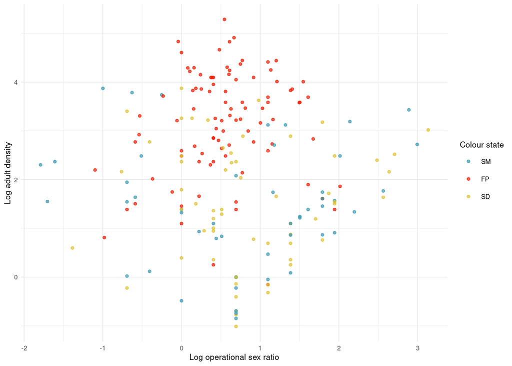

```r
pdat <- ggplot(data = ecodat2, aes(x = log(OSR), y = log(dens), colour = FemState)) +
  geom_point(alpha = 0.7, size = 1) +
  labs(x = "Log operational sex ratio", y = "Log adult density") +

  guides(fill = guide_legend(ncol = 1, byrow = TRUE), color = NULL) +
  scale_fill_manual(
    breaks = c(0,1,2),
    values = pal[c(1,12,7)],
    labels = c("SM", "FP", "SD"),
    name = "Colour state"
  ) +
  scale_colour_manual(
    breaks = c(0,1,2),
    values = pal[c(1,12,7)],
    labels = c("SM", "FP", "SD"),
    name = "Colour state"
  ) +
  theme_minimal(base_size = 8)
pdat
```

```r
#ggsave(pdat,
#       filename = "~/Dropbox/Doctorado/COEN_Comparative/Writing/Figures/De_dat.pdf", device = "pdf", units = "mm", width = 60, height = 40)
```

### Effects of adult density on the occurrence of FPs

In *Model 3* we ask if the probability of FP increases with adult density at breeding sites.

#### Run the model

```r
inv.phylo<-inverseA(ecotre2,nodes="TIPS",scale=TRUE)

# residual covariance matrix 1/J*(I+J), I and J are identity and unit matrices respectively
IJ <- (1/3) * (diag(2) + matrix(1, 2, 2))

# kronecker prior for fixed effect close to being flat for the 2 way:
#(0 vs.1 , 1 vs. 2 and 0 vs. 2) marginal probabilities within each fixed effect

prDem1 = list(
  B = list(mu = rep(0, 4), V = diag(4) * (1.7 + pi ^ 2 / 3)),
  R = list(V = IJ, fix = 1),
  G = list(
    G1 = list(
      V = 1,
      nu = 1000,
      alpha.mu = rep(0, 1),
      alpha.V = diag(1)
    ),
    G2 = list(
      V = 1,
      nu = 1000,
      alpha.mu = rep(0, 1),
      alpha.V = diag(1)
    )
  )
)


# the model for the effect of density
# with SM as baseline
mm3.1 <- MCMCglmm(
  relevel(FemState, ref = "0") ~ trait + log(dens):trait,
  random = ~ Site + Taxon,
  rcov = ~ us(trait):units,
  ginverse = list(Taxon = inv.phylo$Ainv),
  family = "categorical",
  data = ecodat2,
  prior = prDem1,
  pl = TRUE,
  slice = TRUE,
  nitt = 330000,
  burnin = 30000,
  thin = 100,
  verbose = F
)

# with SD as baseline
mm3.2 <- MCMCglmm(
  relevel(FemState, ref = "2") ~ trait + log(dens):trait,
  random = ~ Site + Taxon,
  rcov = ~ us(trait):units,
  ginverse = list(Taxon = inv.phylo$Ainv),
  family = "categorical",
  data = ecodat2,
  prior = prDem1,
  pl = TRUE,
  slice = TRUE,
  nitt = 330000,
  burnin = 30000,
  thin = 100,
  verbose = F
)
```

#### Get estimates in response scale

```r
# rescale estimates assuming residual covariance matrix of zero
Delta <- cbind(c(-1, 1, 0), c(-1, 0, 1))
c2 <- (16 * sqrt(3)/(15 * pi))^2
D <- ginv(Delta %*% t(Delta)) %*% Delta

dens<-log(ecodat2$dens)

# make the estimate data frame
Pred<-data.frame(SM.mean = numeric(length = length(dens)),
                 FP.mean = numeric(length = length(dens)),
                 SD.mean = numeric(length = length(dens)),
                 SM.lwr = numeric(length = length(dens)),
                 FP.lwr = numeric(length = length(dens)),
                 SD.lwr = numeric(length = length(dens)),
                 SM.upr = numeric(length = length(dens)),
                 FP.upr = numeric(length = length(dens)),
                 SD.upr = numeric(length = length(dens)))
Pred$dens <- dens

Int<-data.frame(SM = numeric(length = 2*nrow(mm3.1$Sol)),
                FP = numeric(length = 2*nrow(mm3.1$Sol)),
                SD = numeric(length = 2*nrow(mm3.1$Sol)))

for (i in 1:length(dens)){

  # rescale the estimates as if the residual covariance matrix was zero
  Int1 <- t(apply((mm3.1$Sol[, 1:2]+dens[i]*mm3.1$Sol[, 3:4]), 1, function(x) {
    D %*% (x/sqrt(1 + c2 * diag(IJ))
    )
  }))

 Int2 <- t(apply((mm3.2$Sol[, 1:2]+dens[i]*mm3.2$Sol[, 3:4]), 1, function(x) {
    D %*% (x/sqrt(1 + c2 * diag(IJ))
    )
  }))

 Int <- rbind(Int1, Int2[,c(2,3,1)])

  # median probability
  Pred$SM.mean[i] <- mean(mcmc(exp(Int[,1])/rowSums(exp(Int))))
  Pred$FP.mean[i] <- mean(mcmc(exp(Int[,2])/rowSums(exp(Int))))
  Pred$SD.mean[i] <- mean(mcmc(exp(Int[,3])/rowSums(exp(Int))))

  # lower HPD interval
  Pred$SM.lwr[i] <- HPDinterval(mcmc(exp(Int[,1])/rowSums(exp(Int))))[1]
  Pred$FP.lwr[i] <- HPDinterval(mcmc(exp(Int[,2])/rowSums(exp(Int))))[1]
  Pred$SD.lwr[i] <- HPDinterval(mcmc(exp(Int[,3])/rowSums(exp(Int))))[1]

  # upper HPD interval
  Pred$SM.upr[i] <- HPDinterval(mcmc(exp(Int[,1])/rowSums(exp(Int))))[2]
  Pred$FP.upr[i] <- HPDinterval(mcmc(exp(Int[,2])/rowSums(exp(Int))))[2]
  Pred$SD.upr[i] <- HPDinterval(mcmc(exp(Int[,3])/rowSums(exp(Int))))[2]
}
```

#### Plot predicted

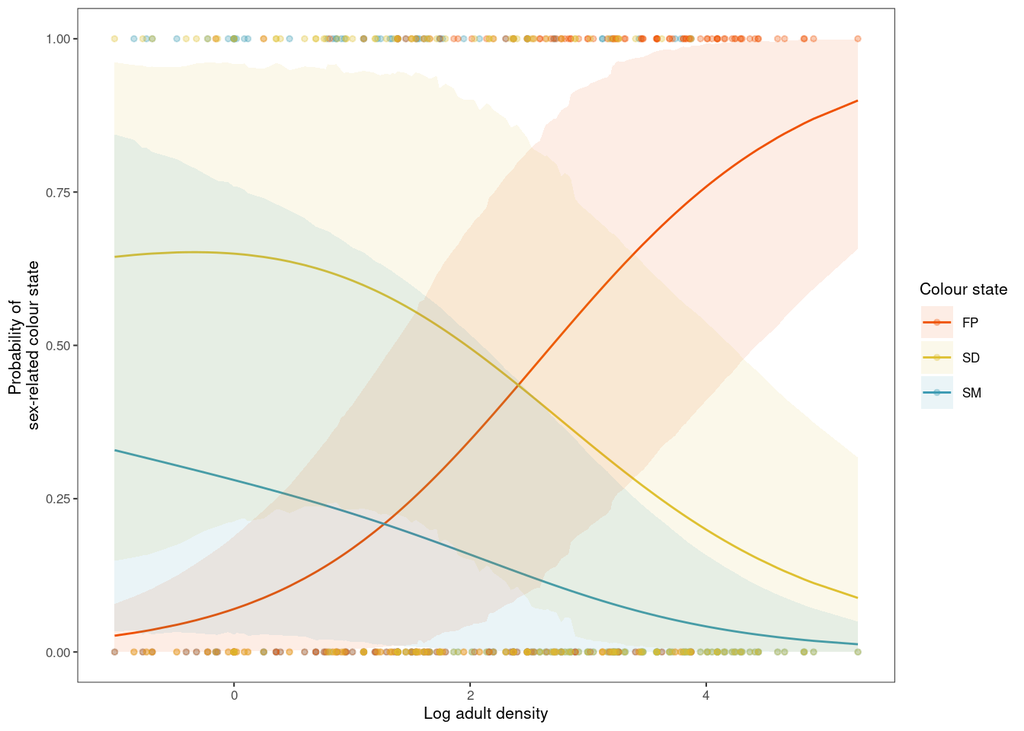

```r
# melt for plotting
Pred$sample <- rownames(Pred)

Pdat <- data.frame(dens = rep(dens,3))
Pdat$FemState <- rep(c("SM","FP", "SD"), each = length(dens))

Pdat$mean <- reshape::melt(Pred[,c(11,1:3)], id.vars = "sample")[,3]
Pdat$lwr <- reshape::melt(Pred[,c(11,4:6)], id.vars = "sample")[,3]
Pdat$upr <- reshape::melt(Pred[,c(11,7:9)], id.vars = "sample")[,3]

#head(Pdat)

# get species data points
Mdata <- data.frame(taxon = ecodat2$Taxon,
                  dens = log(ecodat2$dens),
                  SM = numeric(length(ecodat2$Taxon)),
                  FP = numeric(length(ecodat2$Taxon)),
                  SD = numeric(length(ecodat2$Taxon)))

for (i in 1:nrow(Mdata)){
  if(ecodat2$FemState[i] == 0){
    Mdata$SM[i] <- 1}
  else{
    if(ecodat2$FemState[i] == 1){
      Mdata$FP[i] <-1}
    else{
      Mdata$SD[i] <-1
    }
  }
}

#head(Mdata)
# melt for plotting
MdataPlot <- reshape::melt(Mdata, id.vars = c("taxon", "dens"))
colnames(MdataPlot)[3:4] <- c("FemState", "mean")

pal <- wes_palette("Zissou1", 12, type = "continuous")
p3.2 <- ggplot(data = Pdat, aes(x=dens, y =mean, color = FemState ))+
  geom_line(linewidth=0.5, show.legend = NA)+
  theme_bw(base_size = 8)+
  geom_ribbon(aes(ymax = upr, ymin = lwr, x=dens, fill=FemState),color=NA, alpha = 0.1)+
  geom_point(data = MdataPlot, aes(color = FemState, fill = FemState), alpha = 0.3 , size = 1, position = position_jitter(height = 0,) )+
  ylab(label = "Probability of \nsex-related colour state")+
  xlab(label="Log adult density")+ # xlim(0,80)+
  scale_color_manual(breaks = c("FP", "SD", "SM"),
                     values = c(pal[c(11,7,1)]),
                     name = "Colour state") +
  scale_fill_manual(breaks = c("FP", "SD", "SM"),
                    values = c(pal[c(11,7,1)]),
                    name = "Colour state") +
  theme(panel.grid.major = element_blank(), panel.grid.minor = element_blank())

p3.2
```

```r
#ggsave(p3.2,  filename = "~/Dropbox/Doctorado/COEN_Comparative/Writing/Figures/dens_FP.pdf", device = "pdf", units = "mm", width = 100, height = 50)
```

#### Get log-odds estimates

```r
dens<-log(ecodat2$dens)

# make the estimate data frame
Pred<-data.frame(FPvSM.mean = numeric(length = length(dens)),
                 FPvSD.mean = numeric(length = length(dens)),
                 FPvSM.lwr = numeric(length = length(dens)),
                 FPvSD.lwr = numeric(length = length(dens)),
                 FPvSM.upr = numeric(length = length(dens)),
                 FPvSD.upr = numeric(length = length(dens)))
Pred$dens <- dens

for (i in 1:length(dens)){

   # median probability
  Pred$FPvSM.mean[i] <- mean(mm3.1$Sol[,1] + dens[i] * mm3.1$Sol[,3])
  Pred$FPvSD.mean[i] <- mean(mm3.2$Sol[,2] + dens[i] * mm3.2$Sol[,4])


  # lower HPD interval
  Pred$FPvSM.lwr[i] <- HPDinterval(mcmc(mm3.1$Sol[,1] + dens[i] * mm3.1$Sol[,3]))[1]
  Pred$FPvSD.lwr[i] <- HPDinterval(mcmc(mm3.2$Sol[,2] + dens[i] * mm3.2$Sol[,4]))[1]

  # upper HPD interval
  Pred$FPvSM.upr[i] <- HPDinterval(mcmc(mm3.1$Sol[,1] + dens[i] * mm3.1$Sol[,3]))[2]
  Pred$FPvSD.upr[i] <- HPDinterval(mcmc(mm3.2$Sol[,2] + dens[i] * mm3.2$Sol[,4]))[2]

}
```

#### Plot log odds

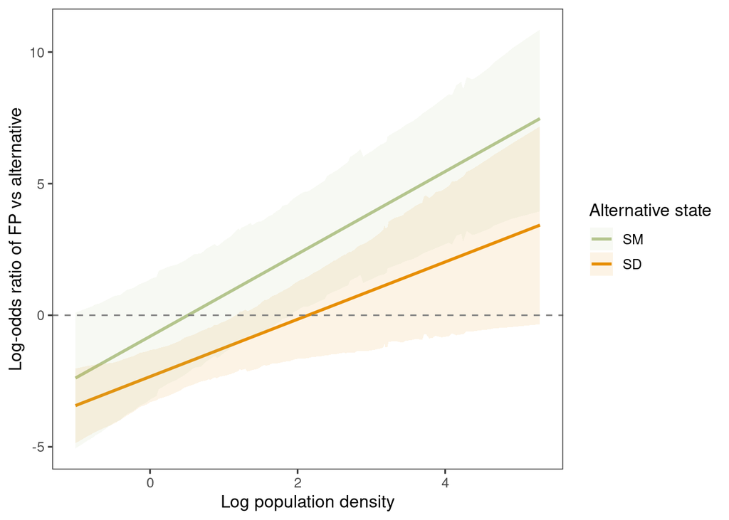

```r
# melt for plotting
Pred$sample <- rownames(Pred)

Pdat <- data.frame(dens = rep(dens,2))
Pdat$FemState <- rep(c("FPvsSM","FPvsSD"), each = length(dens))

Pdat$mean <- reshape::melt(Pred[,c(8,1:2)], id.vars = "sample")[,3]
Pdat$lwr <- reshape::melt(Pred[,c(8,3:4)], id.vars = "sample")[,3]
Pdat$upr <- reshape::melt(Pred[,c(8,5:6)], id.vars = "sample")[,3]

#head(Pdat)

pal <- wes_palette("Zissou1", 12, type = "continuous")
pm3 <- ggplot(data = Pdat, aes(x=dens, y =mean, color = FemState ))+
  geom_line(linewidth=1, show.legend = NA)+
  theme_bw(base_size = 12)+
  geom_ribbon(aes(ymax = upr, ymin = lwr, x=dens, fill=FemState),color=NA, alpha = 0.1)+
  ylab(label = "Log-odds ratio of FP vs alternative")+
  xlab(label="Log population density")+ #xlim(0,80)+
  scale_color_manual(breaks = c("FPvsSM", "FPvsSD"),
                     values = c(pal[c(5,9)]),
                     labels = c("SM", "SD"),
                     name = "Alternative state") +
  scale_fill_manual(breaks = c("FPvsSM", "FPvsSD"),
                    values = c(pal[c(5,9)]),
                    labels = c("SM", "SD"),
                    name = "Alternative state") +
  geom_hline(yintercept = 0, colour = "gray50", lty = 2) +
  theme(panel.grid.major = element_blank(), panel.grid.minor = element_blank())

pm3
```

#### Hypothesis test

```r
n <- nrow(mm3.1$Sol)

Model3.summ <- data.frame(Log_odds = c("FP_vs_SM", "FP_vs_SD"),
                          PM = c(mean(mm3.1$Sol[,3]), mean(mm3.2$Sol[,4])),
                          Lwr = c(HPDinterval(mm3.1$Sol[,3])[1],
                                  HPDinterval(mm3.2$Sol[,4])[1]),
                          Upr = c(HPDinterval(mm3.1$Sol[,3])[2],
                                  HPDinterval(mm3.2$Sol[,4])[2]),
                          PMCMC = c(sum(mm3.1$Sol[,3] < 0) / n,
                                    sum(mm3.2$Sol[,4] < 0) / n))

 Model3.summ %>%
  kbl(booktabs =T, align= c(rep('l',1),rep('r', 4))) %>%
  kable_styling(latex_options ="striped")
```

| Log_odds | PM | Lwr | Upr | PMCMC |
| --- | --- | --- | --- | --- |
| FP_vs_SM | 1.565960 | 0.9219430 | 2.256258 | 0.0000000 |
| FP_vs_SD | 1.089187 | 0.3597969 | 1.863109 | 0.0006667 |

### Effects of OSR on the occurrence of FPs

#### Run the mode

```r
inv.phylo<-inverseA(ecotre2,nodes="TIPS",scale=TRUE)

#residual covariance matrix 1/J*(I+J), I and J are identity and unit matrices respectively
IJ <- (1/3) * (diag(2) + matrix(1, 2, 2))

# kronecker prior for fixed effect close to being flat for the 2 way:
#(0 vs.1 , 1 vs. 2 and 0 vs. 2) marginal probabilities within each fixed effect

prDem2 = list(
  B = list(mu = rep(0, 4), V = diag(4) * (1.7 + pi ^ 2 / 3)),
  R = list(V = IJ, fix = 1),
  G = list(
    G1 = list(
      V = 1,
      nu = 1000,
      alpha.mu = rep(0, 1),
      alpha.V = diag(1)
    ),
    G2 = list(
      V = 1,
      nu = 1000,
      alpha.mu = rep(0, 1),
      alpha.V = diag(1)
    )
  )
)


#The model for the effect of OSR
mm4.1 <- MCMCglmm(
  relevel(FemState, ref = "0") ~ trait + log(OSR):trait,
  random = ~ Site + Taxon,
  rcov = ~ us(trait):units,
  ginverse = list(Taxon = inv.phylo$Ainv),
  family = "categorical",
  data = ecodat2,
  prior = prDem2,
  pl = TRUE,
  slice = TRUE,
  nitt = 330000,
  burnin = 30000,
  thin = 100,
  verbose = F
)

mm4.2 <- MCMCglmm(
  relevel(FemState, ref = "2") ~ trait + log(OSR):trait,
  random = ~ Site + Taxon,
  rcov = ~ us(trait):units,
  ginverse = list(Taxon = inv.phylo$Ainv),
  family = "categorical",
  data = ecodat2,
  prior = prDem2,
  pl = TRUE,
  slice = TRUE,
  nitt = 330000,
  burnin = 30000,
  thin = 100,
  verbose = F
)
```

#### Get estimates in response scale

```r
# rescale estimates assuming residual covariance matrix of zero
Delta <- cbind(c(-1, 1, 0), c(-1, 0, 1))
c2 <- (16 * sqrt(3)/(15 * pi))^2
D <- ginv(Delta %*% t(Delta)) %*% Delta

OSR <- log(ecodat2$OSR)

# make the estimate data frame
Pred <- data.frame(SM.mean = numeric(length = length(OSR)),
                 FP.mean = numeric(length = length(OSR)),
                 SD.mean = numeric(length = length(OSR)),
                 SM.lwr = numeric(length = length(OSR)),
                 FP.lwr = numeric(length = length(OSR)),
                 SD.lwr = numeric(length = length(OSR)),
                 SM.upr = numeric(length = length(OSR)),
                 FP.upr = numeric(length = length(OSR)),
                 SD.upr = numeric(length = length(OSR)))
Pred$OSR <- OSR

Int <- data.frame(SM = numeric(length = 2*nrow(mm4.1$Sol)),
                FP = numeric(length = 2*nrow(mm4.1$Sol)),
                SD = numeric(length = 2*nrow(mm4.1$Sol)))

for (i in 1:length(OSR)){

  # rescale the estimates as if the residual covariance matrix was zero
  Int1 <- t(apply((mm4.1$Sol[, 1:2]+OSR[i]*mm4.1$Sol[, 3:4]), 1, function(x) {
    D %*% (x/sqrt(1 + c2 * diag(IJ))
    )
  }))

 Int2 <- t(apply((mm4.2$Sol[, 1:2]+OSR[i]*mm4.2$Sol[, 3:4]), 1, function(x) {
    D %*% (x/sqrt(1 + c2 * diag(IJ))
    )
  }))

 Int <- rbind(Int1, Int2[,c(2,3,1)])

  # median probability
  Pred$SM.mean[i] <- mean(mcmc(exp(Int[,1])/rowSums(exp(Int))))
  Pred$FP.mean[i] <- mean(mcmc(exp(Int[,2])/rowSums(exp(Int))))
  Pred$SD.mean[i] <- mean(mcmc(exp(Int[,3])/rowSums(exp(Int))))

  # lower HPD interval
  Pred$SM.lwr[i] <- HPDinterval(mcmc(exp(Int[,1])/rowSums(exp(Int))))[1]
  Pred$FP.lwr[i] <- HPDinterval(mcmc(exp(Int[,2])/rowSums(exp(Int))))[1]
  Pred$SD.lwr[i] <- HPDinterval(mcmc(exp(Int[,3])/rowSums(exp(Int))))[1]

  # upper HPD interval
  Pred$SM.upr[i] <- HPDinterval(mcmc(exp(Int[,1])/rowSums(exp(Int))))[2]
  Pred$FP.upr[i] <- HPDinterval(mcmc(exp(Int[,2])/rowSums(exp(Int))))[2]
  Pred$SD.upr[i] <- HPDinterval(mcmc(exp(Int[,3])/rowSums(exp(Int))))[2]
}
```

#### Plot predicted

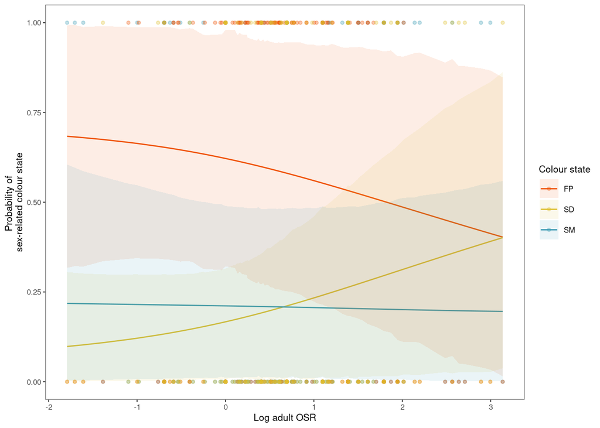

```r
# melt for plotting
Pred$sample<-rownames(Pred)

Pdat<-data.frame(OSR = rep(OSR,3))
Pdat$FemState<-rep(c("SM","FP", "SD"), each = length(OSR))

Pdat$mean<-reshape::melt(Pred[,c(11,1:3)], id.vars = "sample")[,3]
Pdat$lwr<-reshape::melt(Pred[,c(11,4:6)], id.vars = "sample")[,3]
Pdat$upr<-reshape::melt(Pred[,c(11,7:9)], id.vars = "sample")[,3]

#head(Pdat)

# get species data points
Mdata<-data.frame(taxon = ecodat2$Taxon,
                  OSR = log(ecodat2$OSR),
                  SM = numeric(length(ecodat2$Taxon)),
                  FP = numeric(length(ecodat2$Taxon)),
                  SD = numeric(length(ecodat2$Taxon)))

for (i in 1:nrow(Mdata)){
  if(ecodat2$FemState[i] == 0){
    Mdata$SM[i] <- 1}
  else{
    if(ecodat2$FemState[i] == 1){
      Mdata$FP[i] <-1}
    else{
      Mdata$SD[i] <-1
    }
  }
}

#head(Mdata)
# melt for plotting
MdataPlot<-reshape::melt(Mdata, id.vars = c("taxon", "OSR"))
colnames(MdataPlot)[3:4]<-c("FemState", "mean")

pal <- wes_palette("Zissou1", 12, type = "continuous")
p4.2<-ggplot(data = Pdat, aes(x=OSR, y =mean, color = FemState ))+
  geom_line(linewidth=0.5, show.legend = NA)+
  theme_bw(base_size = 8)+
  geom_ribbon(aes(ymax = upr, ymin = lwr, x=OSR, fill=FemState),color=NA, alpha = 0.1)+
  geom_point(data = MdataPlot, aes(color = FemState, fill = FemState), alpha = 0.3 , size = 1, position = position_jitter(height = 0,) )+
  ylab(label = "Probability of \nsex-related colour state")+
  xlab(label="Log adult OSR")+ # xlim(0,80)+
  scale_color_manual(breaks = c("FP", "SD", "SM"),
                     values = c(pal[c(11,7,1)]),
                     name = "Colour state") +
  scale_fill_manual(breaks = c("FP", "SD", "SM"),
                    values = c(pal[c(11,7,1)]),
                    name = "Colour state") +
  theme(panel.grid.major = element_blank(), panel.grid.minor = element_blank())

p4.2
```

```r
#ggsave(p4.2, filename = "~/Dropbox/Doctorado/COEN_Comparative/Writing/Figures/OSR_FP.pdf", device = "pdf", units = "mm", width = 120, height = 60)
```

#### Get log odds estimates

```r
OSR <- log(ecodat2$OSR)

# make the estimate data frame
Pred <- data.frame(FPvSM.mean = numeric(length = length(OSR)),
                 FPvSD.mean = numeric(length = length(OSR)),
                 FPvSM.lwr = numeric(length = length(OSR)),
                 FPvSD.lwr = numeric(length = length(OSR)),
                 FPvSM.upr = numeric(length = length(OSR)),
                 FPvSD.upr = numeric(length = length(OSR)))
Pred$OSR <- OSR

Int<-data.frame(MA = numeric(length = nrow(mm4.1$Sol)),
                FP = numeric(length = nrow(mm4.1$Sol)),
                MH = numeric(length = nrow(mm4.1$Sol)))

for (i in 1:length(OSR)){

   # median probability
  Pred$FPvSM.mean[i] <- mean(mm4.1$Sol[,1] + OSR[i] * mm4.1$Sol[,3])
  Pred$FPvSD.mean[i] <- mean(mm4.2$Sol[,2] + OSR[i] * mm4.2$Sol[,4])


  # lower HPD interval
  Pred$FPvSM.lwr[i] <- HPDinterval(mcmc(mm4.1$Sol[,1] + OSR[i] * mm4.1$Sol[,3]))[1]
  Pred$FPvSD.lwr[i] <- HPDinterval(mcmc(mm4.2$Sol[,2] + OSR[i] * mm4.2$Sol[,4]))[1]

  # upper HPD interval
  Pred$FPvSM.upr[i] <- HPDinterval(mcmc(mm4.1$Sol[,1] + OSR[i] * mm4.1$Sol[,3]))[2]
  Pred$FPvSD.upr[i] <- HPDinterval(mcmc(mm4.2$Sol[,2] + OSR[i] * mm4.2$Sol[,4]))[2]

}
```

#### Plot log odds

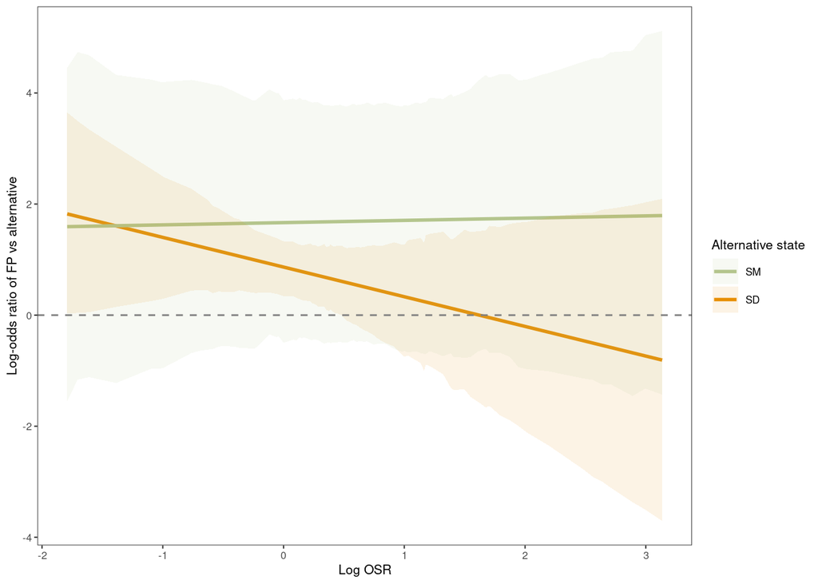

```r
# melt for plotting
Pred$sample<-rownames(Pred)

Pdat<-data.frame(OSR = rep(OSR,2))
Pdat$FemState<-rep(c("FPvsSM","FPvsSD"), each = length(OSR))

Pdat$mean<-reshape::melt(Pred[,c(8,1:2)], id.vars = "sample")[,3]
Pdat$lwr<-reshape::melt(Pred[,c(8,3:4)], id.vars = "sample")[,3]
Pdat$upr<-reshape::melt(Pred[,c(8,5:6)], id.vars = "sample")[,3]

#head(Pdat)

pal <- wes_palette("Zissou1", 12, type = "continuous")
pm4 <-ggplot(data = Pdat, aes(x=OSR, y =mean, color = FemState ))+
  geom_line(linewidth=1, show.legend = NA)+
  theme_bw(base_size = 8)+
  geom_ribbon(aes(ymax = upr, ymin = lwr, x=OSR, fill=FemState),color=NA, alpha = 0.1)+
  ylab(label = "Log-odds ratio of FP vs alternative")+
  xlab(label="Log OSR")+ #xlim(0,80)+
  scale_color_manual(breaks = c("FPvsSM", "FPvsSD"),
                     values = c(pal[c(5,9)]),
                     labels = c("SM", "SD"),
                     name = "Alternative state") +
  scale_fill_manual(breaks = c("FPvsSM", "FPvsSD"),
                    values = c(pal[c(5,9)]),
                    labels = c("SM", "SD"),
                    name = "Alternative state") +
  geom_hline(yintercept = 0, colour = "gray50", lty = 2) +
  theme(panel.grid.major = element_blank(), panel.grid.minor = element_blank())

pm4
```

#### Hypothesis test

```r
n <- nrow(mm4.1$Sol)

Model4.summ <- data.frame(Log_odds = c("FP_vs_SM", "FP_vs_SD"),
                          PM = c(mean(mm4.1$Sol[,3]), mean(mm4.2$Sol[,4])),
                          Lwr = c(HPDinterval(mm4.1$Sol[,3])[1],
                                  HPDinterval(mm4.2$Sol[,4])[1]),
                          Upr = c(HPDinterval(mm4.1$Sol[,3])[2],
                                  HPDinterval(mm4.2$Sol[,4])[2]),
                          PMCMC = c(sum(mm4.1$Sol[,3] < 0) / n,
                                    sum(mm4.2$Sol[,4] < 0) / n))

 Model4.summ %>%
  kbl(booktabs =T, align= c(rep('l',1),rep('r', 4))) %>%
  kable_styling(latex_options ="striped")
```

| Log_odds | PM | Lwr | Upr | PMCMC |
| --- | --- | --- | --- | --- |
| FP_vs_SM | 0.0404340 | -0.8636201 | 0.9877665 | 0.4800000 |
| FP_vs_SD | -0.5342587 | -1.4850277 | 0.3869343 | 0.8646667 |